# Cases of Data Science PG

Secary M

Trimester 1, 2025

# 1 DS_CS01_Linear_Regression_Fuel_Economy

## 1.1 Case study

#### 1.1.0.1 Set up libraries

```r
pacman::p_load(
  tidyverse,
  tidymodels,
  AppliedPredictiveModeling,
  skimr,
  janitor,
  corrplot,
  vip
)
```

#### 1.1.0.2 Read in data

```r
data(FuelEconomy, package = "AppliedPredictiveModeling")
```

#### 1.1.0.3 Pre-processing

###### 1.1.0.3.0.1 Convert to tibble

```r
cars2010 <- as_tibble(cars2010)
```

###### 1.1.0.3.0.2 Clean names and select predictors

```r
cars2010 <- clean_names(cars2010)
cars2010 <-
  cars2010 %>%
  select(
    eng_displ,
    num_cyl,
    FE = fe,
    num_gears,
    drive_desc
  )
cars2010
```

```
## # A tibble: 1,107 × 5
##    eng_displ num_cyl    FE num_gears drive_desc
##        <dbl>   <int> <dbl>     <int> <fct>
##  1       4.7       8  28.0         6 TwoWheelDriveRear
##  2       4.7       8  25.6         6 TwoWheelDriveRear
##  3       4.2       8  26.8         6 AllWheelDrive
##  4       4.2       8  25.0         6 AllWheelDrive
##  5       5.2      10  24.8         6 AllWheelDrive
##  6       5.2      10  23.9         6 AllWheelDrive
##  7       2         4  39.7         6 AllWheelDrive
##  8       6        12  24.4         6 AllWheelDrive
##  9       3         6  39.7         6 TwoWheelDriveRear
## 10       3         6  38.8         6 TwoWheelDriveRear
## # ℹ 1,097 more rows
```

###### 1.1.0.3.0.3 Recode the drive predictor

```r
cars2010 %>%
  count(drive_desc)
```

```
## # A tibble: 5 × 2
##   drive_desc                 n
##   <fct>                  <int>
## 1 AllWheelDrive            205
## 2 FourWheelDrive           159
## 3 ParttimeFourWheelDrive    11
## 4 TwoWheelDriveFront       382
## 5 TwoWheelDriveRear        350
```

```r
cars2010<-
  cars2010 %>%
  mutate(
    drive = case_when(
      str_detect(drive_desc, "Front") ~ "front",
      str_detect(drive_desc, "Rear") ~ "rear",
      TRUE ~ "4WD"
    ))
cars2010 %>%
  count(drive_desc, drive)
```

```
## # A tibble: 5 × 3
##   drive_desc             drive     n
##   <fct>                  <chr> <int>
## 1 AllWheelDrive          4WD     205
## 2 FourWheelDrive         4WD     159
## 3 ParttimeFourWheelDrive 4WD      11
## 4 TwoWheelDriveFront     front   382
## 5 TwoWheelDriveRear      rear    350
```

```r
cars2010 <-
  cars2010 %>%
  select(-drive_desc)
cars2010
```

```
## # A tibble: 1,107 × 5
##    eng_displ num_cyl    FE num_gears drive
##        <dbl>   <int> <dbl>     <int> <chr>
##  1       4.7       8  28.0         6 rear
##  2       4.7       8  25.6         6 rear
##  3       4.2       8  26.8         6 4WD
##  4       4.2       8  25.0         6 4WD
##  5       5.2      10  24.8         6 4WD
##  6       5.2      10  23.9         6 4WD
##  7       2         4  39.7         6 4WD
##  8       6        12  24.4         6 4WD
##  9       3         6  39.7         6 rear
## 10       3         6  38.8         6 rear
## # ℹ 1,097 more rows
```

###### 1.1.0.3.0.4 Convert character into factor

```r
cars2010 <-
  cars2010 %>%
  mutate_if(
    is.character, factor
  )
cars2010
```

```
## # A tibble: 1,107 × 5
##    eng_displ num_cyl    FE num_gears drive
##        <dbl>   <int> <dbl>     <int> <fct>
##  1       4.7       8  28.0         6 rear
##  2       4.7       8  25.6         6 rear
##  3       4.2       8  26.8         6 4WD
##  4       4.2       8  25.0         6 4WD
##  5       5.2      10  24.8         6 4WD
##  6       5.2      10  23.9         6 4WD
##  7       2         4  39.7         6 4WD
##  8       6        12  24.4         6 4WD
##  9       3         6  39.7         6 rear
## 10       3         6  38.8         6 rear
## # ℹ 1,097 more rows
```

###### 1.1.0.3.0.5 Split into training and testing

```r
set.seed(2020)
car_split <- initial_split(cars2010, strata = FE)
car_train <- training(car_split)
car_test <- testing(car_split)
```

#### 1.1.0.4 EDA

###### 1.1.0.4.0.1 Overview

```r
skim(car_train)
```

Table 1.1: Data summary

| Name | car_train |
| --- | --- |
| Number of rows | 829 |
| Number of columns | 5 |
| _______________________ |  |
| Column type frequency: |  |
| factor | 1 |
| numeric | 4 |
| ________________________ |  |
| Group variables | None |

**Variable type: factor**

| skim_variable | n_missing | complete_rate | ordered | n_unique | top_counts |
| --- | --- | --- | --- | --- | --- |
| drive | 0 | 1 | FALSE | 3 | fro: 287, 4WD: 279, rea: 263 |

**Variable type: numeric**

| skim_variable | n_missing | complete_rate | mean | sd | p0 | p25 | p50 | p75 | p100 | hist |
| --- | --- | --- | --- | --- | --- | --- | --- | --- | --- | --- |
| eng_displ | 0 | 1 | 3.51 | 1.33 | 1.0 | 2.40 | 3.5 | 4.3 | 8.40 | ▅▇▃▂▁ |
| num_cyl | 0 | 1 | 5.99 | 1.96 | 2.0 | 4.00 | 6.0 | 8.0 | 16.00 | ▇▇▅▁▁ |
| FE | 0 | 1 | 34.71 | 7.61 | 17.5 | 29.14 | 34.5 | 39.2 | 69.64 | ▃▇▃▁▁ |
| num_gears | 0 | 1 | 5.26 | 1.40 | 1.0 | 5.00 | 6.0 | 6.0 | 8.00 | ▁▁▆▇▂ |

###### 1.1.0.4.0.2 Look at Fuel efficiency

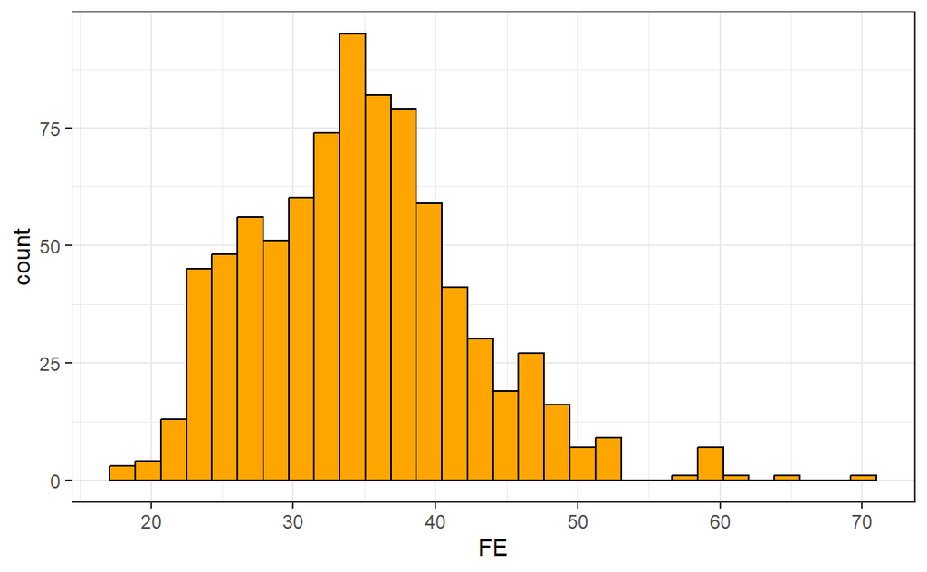

```r
car_train %>%
  ggplot(aes(FE)) +
  geom_histogram(col = "black", fill = "orange")
```

###### 1.1.0.4.0.3 Bivariate relationships

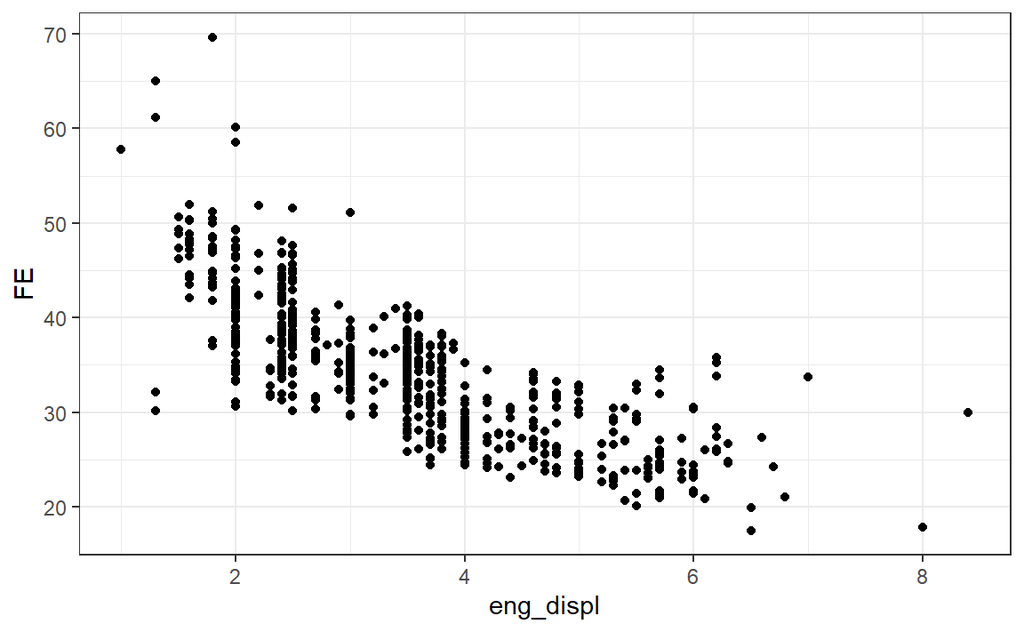

```r
car_train %>%
  ggplot(aes(eng_displ, FE)) +
  geom_point()
```

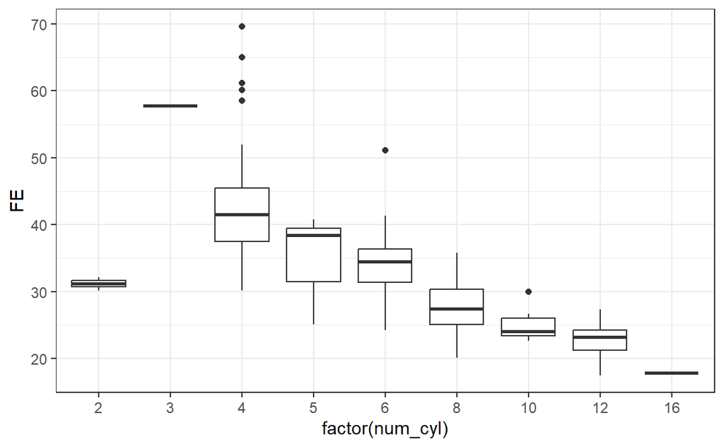

```r
car_train %>%
  ggplot(aes(factor(num_cyl), FE)) +
  geom_boxplot()
```

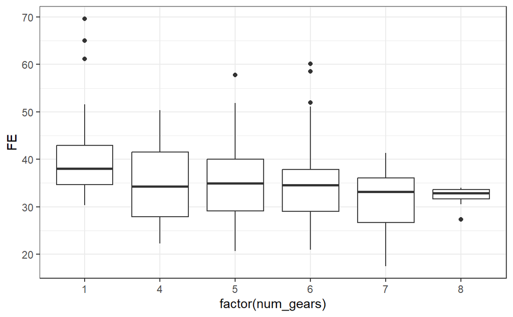

```r
car_train %>%
  ggplot(aes(factor(num_gears), FE)) +
  geom_boxplot()
```

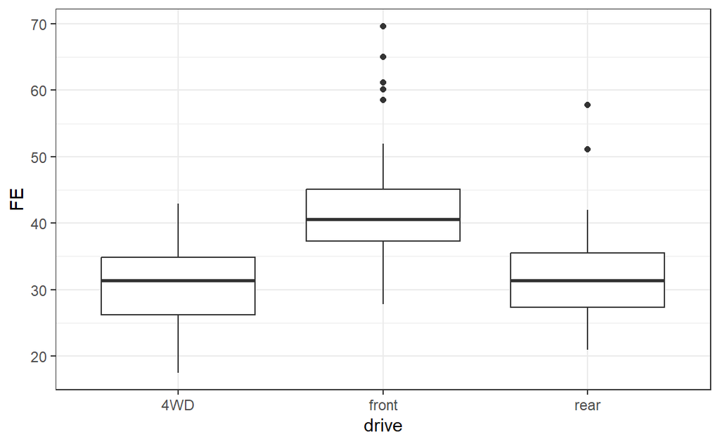

```r
car_train %>%
  ggplot(aes(drive, FE)) + geom_boxplot()
```

###### 1.1.0.4.0.4 Relationship between predictors

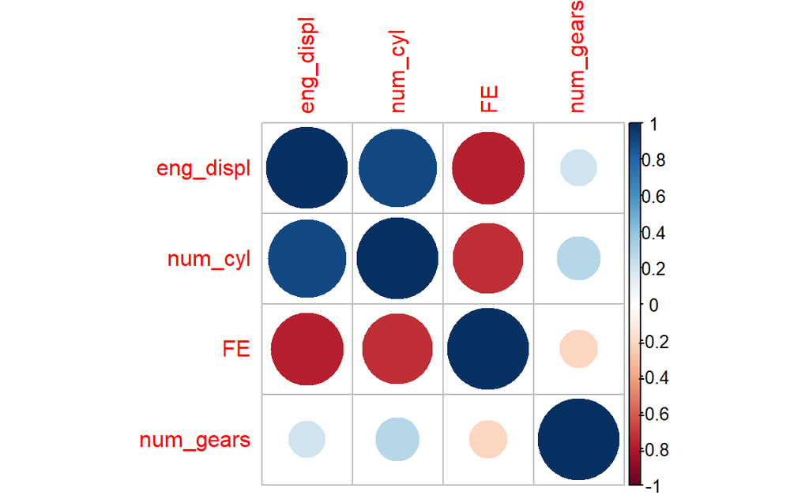

```r
car_train %>%
  select_if(is.numeric) %>%
  cor() %>%
  corrplot()
```

###### 1.1.0.4.0.5 Preprocessing with recipes

```r
car_recipe <-
  recipe(FE ~ ., data = car_train) %>%
  step_poly(eng_displ, degree = 2, options = list(raw = TRUE))
car_recipe
```

```
## ── Recipe ──────────────────────────────────────────────────────────────────────
```

```
## ── Inputs
```

```
## Number of variables by role
```

```
## outcome:   1
## predictor: 4
```

```
## ── Operations
```

```
## • Orthogonal polynomials on: eng_displ
```

```r
car_recipe <- car_recipe %>% prep()
car_recipe
```

```
## ── Recipe ──────────────────────────────────────────────────────────────────────
```

```
## ── Inputs
```

```
## Number of variables by role
```

```
## outcome:   1
## predictor: 4
```

```
## ── Training information
```

```
## Training data contained 829 data points and no incomplete rows.
```

```
## ── Operations
```

```
## • Orthogonal polynomials on: eng_displ | Trained
```

```r
car_train <- car_recipe %>% juice()
car_train
```

```
## # A tibble: 829 × 6
##    num_cyl num_gears drive    FE eng_displ_poly_1 eng_displ_poly_2
##      <int>     <int> <fct> <dbl>            <dbl>            <dbl>
##  1       8         6 rear   28.0              4.7             22.1
##  2       8         6 rear   25.6              4.7             22.1
##  3       8         6 4WD    26.8              4.2             17.6
##  4       8         6 4WD    25.0              4.2             17.6
##  5      12         6 4WD    24.4              6               36
##  6      16         7 4WD    17.8              8               64
##  7       8         7 rear   24.3              4.5             20.2
##  8      12         6 rear   21.0              5.7             32.5
##  9      12         6 rear   21.1              5.7             32.5
## 10      10         6 4WD    25.4              5.2             27.0
## # ℹ 819 more rows
```

```r
car_test <- car_recipe %>% bake(car_test)
car_test
```

```
## # A tibble: 278 × 6
##    num_cyl num_gears drive    FE eng_displ_poly_1 eng_displ_poly_2
##      <int>     <int> <fct> <dbl>            <dbl>            <dbl>
##  1      10         6 4WD    24.8              5.2             27.0
##  2      10         6 4WD    23.9              5.2             27.0
##  3       6         6 rear   39.7              3                9
##  4       6         6 rear   38.8              3                9
##  5       6         7 rear   33.6              3                9
##  6       8         6 rear   27.1              6.2             38.4
##  7       8         6 rear   34.3              6.2             38.4
##  8       6         7 rear   36.2              3.5             12.2
##  9       8         7 rear   30.8              5.5             30.2
## 10       3         5 rear   57.8              1                1
## # ℹ 268 more rows
```

#### 1.1.0.5 Fit model

```r
car_lm <-
  linear_reg() %>%
  set_engine("lm") %>%
  fit(FE ~ ., data = car_train)
car_lm
```

```
## parsnip model object
##
##
## Call:
## stats::lm(formula = FE ~ ., data = data)
##
## Coefficients:
##      (Intercept)           num_cyl         num_gears        drivefront
##         54.90897          -0.55180           0.06216           5.25074
##        driverear  eng_displ_poly_1  eng_displ_poly_2
##          2.24564          -8.28921           0.66325
```

#### 1.1.0.6 Use model

###### 1.1.0.6.0.1 Model fit

```r
car_train %>%
  add_column(
    predict(car_lm, new_data = car_train)
  ) %>%
  yardstick::rmse(truth = FE, estimate = .pred)
```

```
## # A tibble: 1 × 3
##   .metric .estimator .estimate
##   <chr>   <chr>          <dbl>
## 1 rmse    standard        3.94
```

```r
car_test %>%
  add_column(
    predict(car_lm, new_data = car_test)
  ) %>%
  yardstick::rmse(truth = FE, estimate = .pred)
```

```
## # A tibble: 1 × 3
##   .metric .estimator .estimate
##   <chr>   <chr>          <dbl>
## 1 rmse    standard        3.38
```

###### 1.1.0.6.0.2 Check assumptions

```r
car_res <- augment(car_lm$fit)
car_res
```

```
## # A tibble: 829 × 12
##       FE num_cyl num_gears drive eng_displ_poly_1 eng_displ_poly_2 .fitted
##    <dbl>   <int>     <int> <fct>            <dbl>            <dbl>   <dbl>
##  1  28.0       8         6 rear               4.7             22.1    28.8
##  2  25.6       8         6 rear               4.7             22.1    28.8
##  3  26.8       8         6 4WD                4.2             17.6    27.8
##  4  25.0       8         6 4WD                4.2             17.6    27.8
##  5  24.4      12         6 4WD                6               36      22.8
##  6  17.8      16         7 4WD                8               64      22.6
##  7  24.3       8         7 rear               4.5             20.2    29.3
##  8  21.0      12         6 rear               5.7             32.5    25.2
##  9  21.1      12         6 rear               5.7             32.5    25.2
## 10  25.4      10         6 4WD                5.2             27.0    24.6
## # ℹ 819 more rows
## # ℹ 5 more variables: .resid <dbl>, .hat <dbl>, .sigma <dbl>, .cooksd <dbl>,
## #   .std.resid <dbl>
```

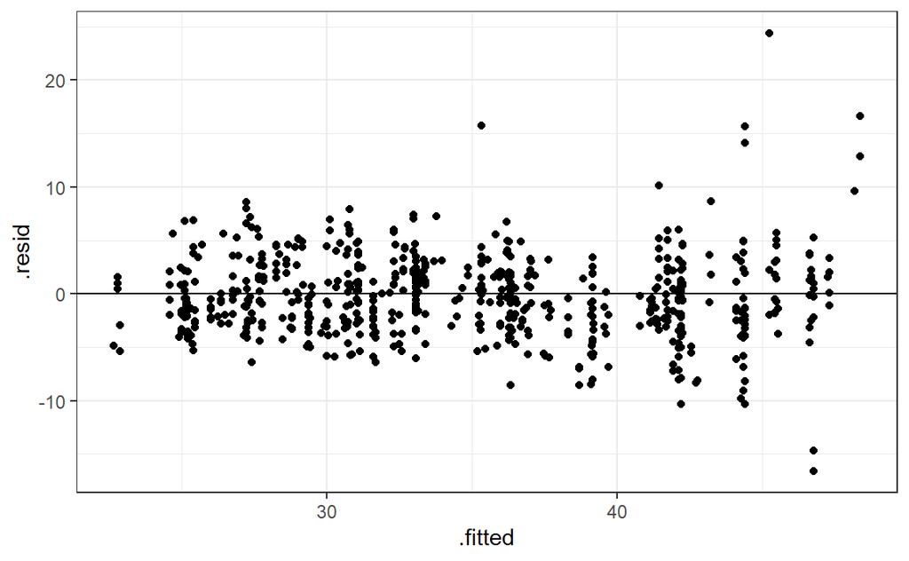

```r
car_res %>%
  ggplot(aes(.fitted, .resid)) +
  geom_point() +
  geom_hline(yintercept = 0)
```

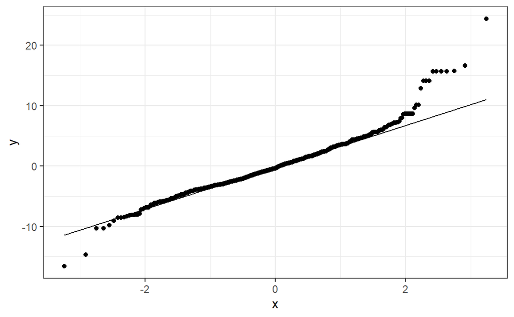

```r
car_res %>%
  ggplot(aes(sample = .resid)) +
  stat_qq() +
  stat_qq_line()
```

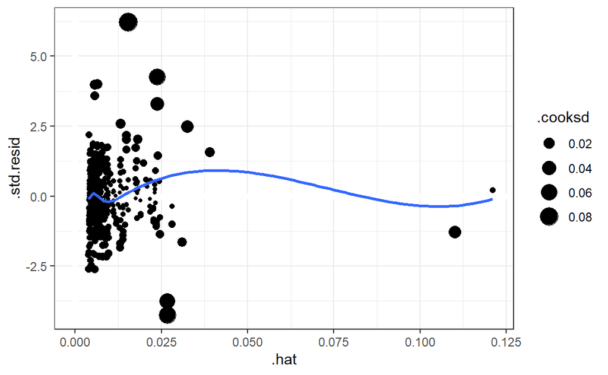

```r
car_res %>%
  ggplot(aes(.hat, .std.resid)) +
  geom_vline(size = 2, colour = "white", xintercept = 0) +
  geom_hline(size = 2, colour = "white", yintercept = 0) +
  geom_point(aes(size = .cooksd)) + geom_smooth(se = FALSE)
```

###### 1.1.0.6.0.3 Variable importance

```r
vi(car_lm)
```

```
## # A tibble: 6 × 3
##   Variable         Importance Sign
##   <chr>                 <dbl> <chr>
## 1 drivefront           13.8   POS
## 2 eng_displ_poly_1     13.4   NEG
## 3 eng_displ_poly_2      9.58  POS
## 4 driverear             6.48  POS
## 5 num_cyl               3.21  NEG
## 6 num_gears             0.590 POS
```

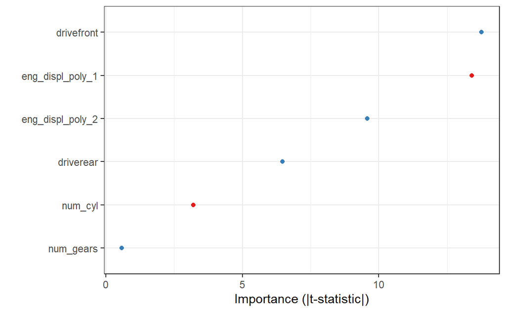

```r
vip(car_lm,
    include_type = TRUE,
    geom = 'point',
    mapping = aes_string(col = "Sign"), size = 5) +
  scale_color_brewer(palette = "Set1")
```

###### 1.1.0.6.0.4 Inference

```r
tidy(car_lm$fit)
```

```
## # A tibble: 7 × 5
##   term             estimate std.error statistic   p.value
##   <chr>               <dbl>     <dbl>     <dbl>     <dbl>
## 1 (Intercept)       54.9       1.24      44.2   2.68e-219
## 2 num_cyl           -0.552     0.172     -3.21  1.37e-  3
## 3 num_gears          0.0622    0.105      0.590 5.55e-  1
## 4 drivefront         5.25      0.382     13.8   6.34e- 39
## 5 driverear          2.25      0.347      6.48  1.59e- 10
## 6 eng_displ_poly_1  -8.29      0.618    -13.4   3.40e- 37
## 7 eng_displ_poly_2   0.663     0.0692     9.58  1.08e- 20
```

```r
tidy(car_lm$fit) %>%
  arrange(p.value)
```

```
## # A tibble: 7 × 5
##   term             estimate std.error statistic   p.value
##   <chr>               <dbl>     <dbl>     <dbl>     <dbl>
## 1 (Intercept)       54.9       1.24      44.2   2.68e-219
## 2 drivefront         5.25      0.382     13.8   6.34e- 39
## 3 eng_displ_poly_1  -8.29      0.618    -13.4   3.40e- 37
## 4 eng_displ_poly_2   0.663     0.0692     9.58  1.08e- 20
## 5 driverear          2.25      0.347      6.48  1.59e- 10
## 6 num_cyl           -0.552     0.172     -3.21  1.37e-  3
## 7 num_gears          0.0622    0.105      0.590 5.55e-  1
```

###### 1.1.0.6.0.5 Prediction

```r
new_data <- tibble(
  num_cyl = 4,
  num_gears = 6,
  eng_displ = 5,
  drive = "front"
)
new_data
```

```
## # A tibble: 1 × 4
##   num_cyl num_gears eng_displ drive
##     <dbl>     <dbl>     <dbl> <chr>
## 1       4         6         5 front
```

```r
new_data <- bake(car_recipe, new_data = new_data)
new_data
```

```
## # A tibble: 1 × 5
##   num_cyl num_gears drive eng_displ_poly_1 eng_displ_poly_2
##     <dbl>     <dbl> <fct>            <dbl>            <dbl>
## 1       4         6 front                5               25
```

```r
predict(car_lm, new_data = new_data)
```

```
## # A tibble: 1 × 1
##   .pred
##   <dbl>
## 1  33.5
```

```r
predict(car_lm, new_data = new_data, type = "pred_int")
```

```
## # A tibble: 1 × 2
##   .pred_lower .pred_upper
##         <dbl>       <dbl>
## 1        25.5        41.4
```

# 2 DS_CS02_Data_Cleaning_Eurovision

## 2.1 Rule 1: Look at the Data

## 2.2 Rule 2: Is There a Package to Deal With That

```r
songs <- jsonlite::fromJSON(glue::glue("{wdpath}/data/eurovision-lyrics.json"))
```

## 2.3 Rule 3: Break it Into Pieces

```r
songs[[1]]
```

```
## $`#`
## [1] "1"
##
## $Country
## [1] "Netherlands"
##
## $`#.1`
## [1] "1"
##
## $Artist
## [1] "Jetty Paerl"
##
## $Song
## [1] "De vogels van Holland"
##
## $Language
## [1] "Dutch"
##
## $Pl.
## [1] "-"
##
## $Sc.
## [1] "-"
##
## $Eurovision_Number
## [1] 1
##
## $Year
## [1] "1956"
##
## $Host_Country
## [1] "Switzerland"
##
## $Host_City
## [1] "Lugano"
##
## $Lyrics
## [1] "De vogels van Holland zijn zo muzikaal\nZe leren in hun prille jeugd al tierelieren\nDe merel, de lijster en de nachtegaal\nOm zo de lente in Holland goed te kunnen vieren\n\nHet is geen wonder, want nergens\nZijn de plassen zo blauw\nAls in Holland - mijnheer\nAls in Holland - mevrouw\nHet …
##
## $`Lyrics translation`
## [1] "The birds of Holland are so musical\nThey already learn to twitter in their early youth\nThe blackbird, the thrush and the nightingale\nSo they can celebrate spring in Holland It's no wonder, because nowhere the puddles are so blue\nAs in Holland, sir\nAs in Holland, madam\nIt's no wonder, b…
```

```r
parse_song <- function(song){
  country <- song$Country
  artist <- song$Artist
  title <- song$Song
  year <- song$Year
  lyrics <- song$Lyrics
  translation <- song$`Lyrics translation`
  place <- song$Pl.
  tibble(
    country, artist, title, year, lyrics, translation, place
  )
}
parse_song(songs[[1]])
```

```
## # A tibble: 1 × 7
##   country     artist      title                 year  lyrics   translation place
##   <chr>       <chr>       <chr>                 <chr> <chr>    <chr>       <chr>
## 1 Netherlands Jetty Paerl De vogels van Holland 1956  "De vog… "The birds… -
```

## 2.4 Rule 4: Get it Into a Tibble

```r
songs <-
  songs %>%
  map_df(parse_song, .id = "ID")
songs
```

```
## # A tibble: 1,644 × 8
##    ID    country        artist              title year  lyrics translation place
##    <chr> <chr>          <chr>               <chr> <chr> <chr>  <chr>       <chr>
##  1 0     Netherlands    Jetty Paerl         De v… 1956  "De v… "The birds… -
##  2 1     Switzerland    Lys Assia           Das … 1956  "Das … "The old c… -
##  3 2     Belgium        Fud Leclerc         Mess… 1956  "Mess… "Ye drowne… -
##  4 3     Germany (West) Walter Andreas Sch… Im W… 1956  "Es g… "There is … -
##  5 4     France         Mathé Altéry        Le t… 1956  "Chan… "Sing, car… -
##  6 5     Luxembourg     Michèle Arnaud      Ne c… 1956  "Si o… "If they t… -
##  7 6     Italy          Franca Raimondi     Apri… 1956  "La p… "The first… -
##  8 7     Netherlands    Corry Brokken       Voor… 1956  "Voor… "Over for … -
##  9 8     Switzerland    Lys Assia (2)       Refr… 1956  "[Int… "Chorus of… 1
## 10 9     Belgium        Mony Marc           Le p… 1956  "Les … "The bells… -
## # ℹ 1,634 more rows
```

## 2.5 Rule 5: Look at Each Column

We need to make sure all of our data makes sense in context. You can find the source data at this link: https://www.kaggle.com/minitree/eurovision-song-lyrics

#### 2.5.0.1 ID

This is an ID number assigned to each song. We should check that the song IDs are all unique.

```r
songs %>% count(ID) %>% filter(n > 1)
```

```
## # A tibble: 0 × 2
## # ℹ 2 variables: ID <chr>, n <int>
```

They are unique, but they’re also not useful, so delete them.

```r
songs <-
  songs %>%
  select(-ID)
songs
```

```
## # A tibble: 1,644 × 7
##    country        artist                 title    year  lyrics translation place
##    <chr>          <chr>                  <chr>    <chr> <chr>  <chr>       <chr>
##  1 Netherlands    Jetty Paerl            De voge… 1956  "De v… "The birds… -
##  2 Switzerland    Lys Assia              Das alt… 1956  "Das … "The old c… -
##  3 Belgium        Fud Leclerc            Messieu… 1956  "Mess… "Ye drowne… -
##  4 Germany (West) Walter Andreas Schwarz Im Wart… 1956  "Es g… "There is … -
##  5 France         Mathé Altéry           Le temp… 1956  "Chan… "Sing, car… -
##  6 Luxembourg     Michèle Arnaud         Ne croi… 1956  "Si o… "If they t… -
##  7 Italy          Franca Raimondi        Aprite … 1956  "La p… "The first… -
##  8 Netherlands    Corry Brokken          Voorgoe… 1956  "Voor… "Over for … -
##  9 Switzerland    Lys Assia (2)          Refrain  1956  "[Int… "Chorus of… 1
## 10 Belgium        Mony Marc              Le plus… 1956  "Les … "The bells… -
## # ℹ 1,634 more rows
```

#### 2.5.0.2 Artist

Are there any artists who appear more than once?

```r
songs %>%
  count(artist) %>%
  arrange(-n)
```

```
## # A tibble: 1,621 × 2
##    artist                  n
##    <chr>               <int>
##  1 Ana Soklič              2
##  2 Benny Cristo            2
##  3 Blas Cantó              2
##  4 Daði og Gagnamagnið     2
##  5 Destiny                 2
##  6 Eden Alene              2
##  7 Efendi                  2
##  8 Gjon's Tears            2
##  9 Go_A                    2
## 10 Hooverphonic            2
## # ℹ 1,611 more rows
```

```r
songs %>%
  filter(str_detect(artist, "Jed"))
```

```
## # A tibble: 2 × 7
##   country artist      title     year  lyrics                   translation place
##   <chr>   <chr>       <chr>     <chr> <chr>                    <chr>       <chr>
## 1 Ireland Jedward     Lipstick  2011  "You say you’re on it b… English     8
## 2 Ireland Jedward (2) Waterline 2012  "Floodgates, can't wait… English     19
```

```r
songs %>%
  filter(country == "Australia")
```

```
## # A tibble: 7 × 7
##   country   artist             title            year  lyrics   translation place
##   <chr>     <chr>              <chr>            <chr> <chr>    <chr>       <chr>
## 1 Australia Guy Sebastian      Tonight Again    2015  "[Verse… English     5
## 2 Australia Dami Im            Sound of Silence 2016  "[Verse… English     2
## 3 Australia Isaiah             Don't Come Easy  2017  "[Verse… English     9
## 4 Australia Jessica Mauboy     We Got Love      2018  "[Verse… English     20
## 5 Australia Kate Miller-Heidke Zero Gravity     2019  "[Verse… English     9
## 6 Australia Montaigne          Don't Break Me   2020  "I don'… English     -
## 7 Australia Montaigne          Technicolour     2021  "I wann… English     -
```

#### 2.5.0.3 Title

```r
songs %>%
  count(title) %>%
  arrange(-n)
```

```
## # A tibble: 1,608 × 2
##    title               n
##    <chr>           <int>
##  1 Shine               4
##  2 Angel               3
##  3 Time                3
##  4 Amen                2
##  5 Attention           2
##  6 Casanova            2
##  7 Coming Home         2
##  8 Congratulations     2
##  9 Fairytale           2
## 10 Goodbye             2
## # ℹ 1,598 more rows
```

#### 2.5.0.4 Year

```r
range(songs$year)
```

```
## [1] "1956" "2021"
```

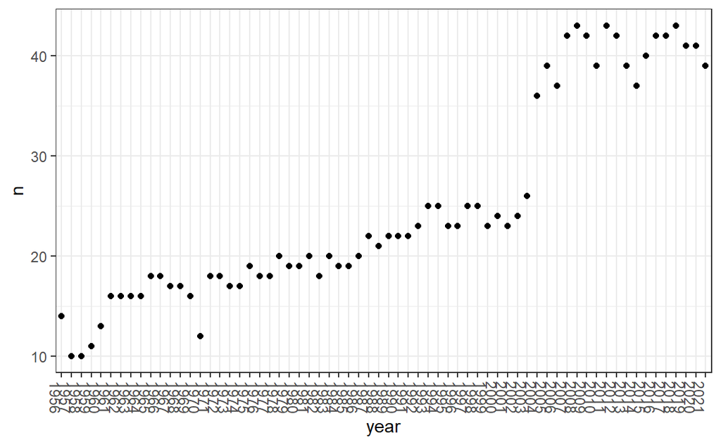

```r
songs %>%
  count(year) %>%
  ggplot(aes(year, n)) +
  geom_point() +
  theme(axis.text.x = element_text(angle = -90, hjust=0))
```

#### 2.5.0.5 Lyrics

```r
songs %>%
  sample_n(5) %>%
  pull(lyrics) %>%
  cat(sep = "\n\n\n")
```

```
## Por vezes dás contigo desanimado
## Por vezes dás contigo a desconfiar
## Por vezes dás contigo sobressaltado
## Por vezes dás contigo a desesperar
##
## De noite ou de dia, a luta é alegria
## E o povo avança é na rua a gritar
##
## De pouco vale o cinto sempre apertado
## De pouco vale andar a lamuriar
## De pouco vale um ar sempre carregado
## De pouco vale a raiva para te ajudar
##
## De noite ou de dia, a luta é alegria
## E o povo avança é na rua a gritar
##
## E traz o pão e traz o queijo e traz o vinho
## E vem o velho e vem o novo e o menino
## E traz o pão e traz o queijo e traz o vinho
## E vem o velho e vem o novo e o menino
## Vem celebrar esta situação e vamos cantar contra a reacção
## Vem celebrar esta situação e vamos cantar contra a reacção
##
## E traz o pão e traz o queijo e traz o vinho
## E vem o velho e vem o novo e o menino
## E traz o pão e traz o queijo e traz o vinho
## E vem o velho e vem o novo e o menino
##
## Não falta quem te avise vai com cuidado
## Não falta quem te queira mandar calar
## Não falta quem te deixe ressabiado
## Não falta quem te venda o próprio ar
##
## De noite ou de dia, a luta é alegria
## E o povo avança é na rua a gritar
##
## E traz o pão e traz o queijo e traz o vinho
## E vem o velho e vem o novo e o menino
## E traz o pão e traz o queijo e traz o vinho
## E vem o velho e vem o novo e o menino
```

[output cut: 167 more lines]

```
## Et qui danse... danse...
## Danse... danse...
## Danse... danse...
##
## Oh, femme, dans sa vie, dans ses rêves aussi
## Femme, dans ses yeux, ses cris, ses aveux
## Femme, femme aimée et femme qui aime
## Femme, élégance, et femme qui danse
##
## Dans ses rêves aussi
## Femme, dans ses yeux, ses cris, ses aveux
## Femme, femme aimée et femme qui aime
## Femme, élégance, et femme qui danse
##
## Qui danse
```

#### 2.5.0.6 Translation

```r
songs %>%
  sample_n(5) %>%
  pull(translation) %>%
  cat(sep = "\n\n\n")
```

```
## English
##
##
## English
##
##
## English
##
##
## Tom Pillibi
## Tom Pillibi has two castles – the first one in Scotland
## Tom Pillibi has two castles – the other one in Montenegro
## He also has two ships which go to the end of the world
## To search for gold and corals and the most beautiful jewels
## He's lucky – Tom Pillibi
## And I think that I'm his girlfriend
## He's so rich, that I envy him
## He's so rich – blasted Tom Pillibi
## Tom Pillibi has two secrets, which he won't tell anyone
## Tom Pillibi has two secrets – I'm the only one who knows them
## The king's daughter smiles to him and waits for him in her bedroom
## The king's daughter smiles to him and the shepherdess too
## He's lucky – Tom Pillibi
## And I think that I'm his girlfriend
## Which good star is looking after him?
## Which good star? – Blasted Tom Pillibi
## Tom Pillibi has only one fault, but it's nothing serious
## Tom Pillibi has only one fault, but it's not such a big thing
## He's charming, he's kind-hearted, he has so much courage
## He's charming, he's kind-hearted, but he's such a liar
## Because nothing exists of all that
## But I don't care when I'm in his arms
## Because I'm the queen of the big country
## Where he takes me to – blasted Tom Pillibi
##
##
## English
```

#### 2.5.0.7 Place

```r
songs %>% count(place)
```

```
## # A tibble: 27 × 2
##    place     n
##    <chr> <int>
##  1 -       309
##  2 1        68
##  3 10       66
##  4 11       58
##  5 12       60
##  6 13       70
##  7 14       59
##  8 15       53
##  9 16       56
## 10 17       48
## # ℹ 17 more rows
```

```r
length(unique(songs$year))
```

```
## [1] 66
```

```r
songs %>%
  count(year, place) %>%
  filter(place == "1") %>%
  arrange(-n)
```

```
## # A tibble: 65 × 3
##    year  place     n
##    <chr> <chr> <int>
##  1 1969  1         4
##  2 1956  1         1
##  3 1957  1         1
##  4 1958  1         1
##  5 1959  1         1
##  6 1960  1         1
##  7 1961  1         1
##  8 1962  1         1
##  9 1963  1         1
## 10 1964  1         1
## # ℹ 55 more rows
```

According to Wikpedia, there were four winners in 1969:

https://en.wikipedia.org/wiki/Eurovision_Song_Contest

> On only one occasion have multiple winners been declared in a single contest: in 1969, four countries finished the contest with an equal number of votes and due to the lack of a tie-break rule at the time, all four countries were declared winners.[7][157]

## 2.7 Rule 7: Create New Columns?

#### 2.7.0.1 Decade

```r
songs
```

```
## # A tibble: 1,644 × 7
##    country        artist                 title    year  lyrics translation place
##    <chr>          <chr>                  <chr>    <chr> <chr>  <chr>       <chr>
##  1 Netherlands    Jetty Paerl            De voge… 1956  "De v… "The birds… -
##  2 Switzerland    Lys Assia              Das alt… 1956  "Das … "The old c… -
##  3 Belgium        Fud Leclerc            Messieu… 1956  "Mess… "Ye drowne… -
##  4 Germany (West) Walter Andreas Schwarz Im Wart… 1956  "Es g… "There is … -
##  5 France         Mathé Altéry           Le temp… 1956  "Chan… "Sing, car… -
##  6 Luxembourg     Michèle Arnaud         Ne croi… 1956  "Si o… "If they t… -
##  7 Italy          Franca Raimondi        Aprite … 1956  "La p… "The first… -
##  8 Netherlands    Corry Brokken          Voorgoe… 1956  "Voor… "Over for … -
##  9 Switzerland    Lys Assia (2)          Refrain  1956  "[Int… "Chorus of… 1
## 10 Belgium        Mony Marc              Le plus… 1956  "Les … "The bells… -
## # ℹ 1,634 more rows
```

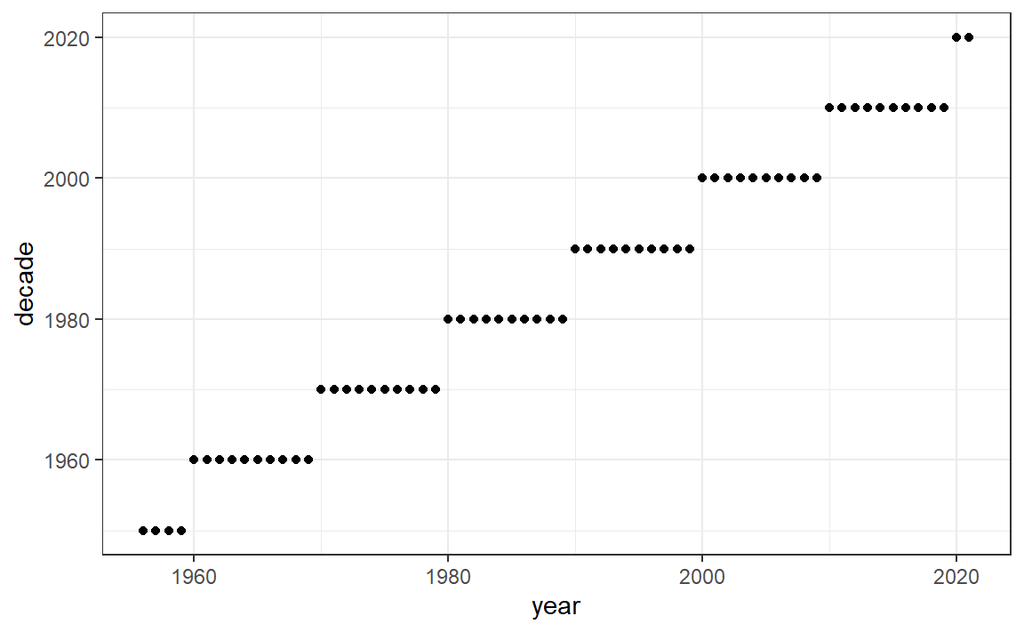

```r
songs <-
  songs %>%
  mutate(
    year = parse_number(year),
    decade = year - year %% 10
  )
songs %>%
  ggplot(aes(year, decade)) +
  geom_point()
```

#### 2.7.0.2 Lyrics

```r
songs %>%
  count(translation) %>%
  arrange(-n)
```

```
## # A tibble: 946 × 2
##    translation                                                                 n
##    <chr>                                                                   <int>
##  1 "English"                                                                 694
##  2 ""                                                                          2
##  3 "Day is turning to evening, is gone, soon forgotten\nBut what we gave …     2
##  4 "God, god, god, god they don’t call you\nCandles, candles, candles, ca…     2
##  5 "Look into my eyes now,\nI'm not a looser, know it!\nI don't surrender…     2
##  6 "Only champions!\nOnly champions! They fly high1 and jump far2.\nAll t…     2
##  7 "\nPure and white, her skin is so inviting\nLike a new, unbeaten snow\…     1
##  8 "\"Come with me\", said my friend\nThe first silent winter snow is fal…     1
##  9 "\"This is the Telephone Information Service, hello\"\n\"Yes, hello, t…     1
## 10 "\"We are all moving around the old circle\"1,\nSinging in this sweet …     1
## # ℹ 936 more rows
```

```r
songs <-
  songs %>%
  mutate(
    english_lyrics = ifelse(
      translation == "English",
      lyrics, translation
    )
  )
```

## 2.8 Rule 7: Save the Data and Write it Up

It’s critically important to make detailed notes about any changes you have made when cleaning the data.

```r
filenamepath <- glue::glue("{wdpath}/data/{lubridate::today()}-eurovision.rds")
filenamepath
```

```
## C:/Users/secar/OneDrive/chtholly/stats7022/exam/prac_exam/data/2025-04-23-eurovision.rds
```

```r
write_rds(songs,filenamepath)
```

# 3 DS_CS03_Pre_processing_Credit_Data

## 3.1 Get data and basic cleaning

#### 3.1.0.1 Read in data

```r
data(credit_data, package = "modeldata")
```

#### 3.1.0.2 Convert to tibble

```r
credit_data <- as_tibble(credit_data)
credit_data
```

```
## # A tibble: 4,454 × 14
##    Status Seniority Home     Time   Age Marital Records Job      Expenses Income
##    <fct>      <int> <fct>   <int> <int> <fct>   <fct>   <fct>       <int>  <int>
##  1 good           9 rent       60    30 married no      freelan…       73    129
##  2 good          17 rent       60    58 widow   no      fixed          48    131
##  3 bad           10 owner      36    46 married yes     freelan…       90    200
##  4 good           0 rent       60    24 single  no      fixed          63    182
##  5 good           0 rent       36    26 single  no      fixed          46    107
##  6 good           1 owner      60    36 married no      fixed          75    214
##  7 good          29 owner      60    44 married no      fixed          75    125
##  8 good           9 parents    12    27 single  no      fixed          35     80
##  9 good           0 owner      60    32 married no      freelan…       90    107
## 10 bad            0 parents    48    41 married no      partime        90     80
## # ℹ 4,444 more rows
## # ℹ 4 more variables: Assets <int>, Debt <int>, Amount <int>, Price <int>
```

#### 3.1.0.3 Clean names

```r
credit_data <- credit_data %>%
  clean_names()
credit_data
```

```
## # A tibble: 4,454 × 14
##    status seniority home     time   age marital records job      expenses income
##    <fct>      <int> <fct>   <int> <int> <fct>   <fct>   <fct>       <int>  <int>
##  1 good           9 rent       60    30 married no      freelan…       73    129
##  2 good          17 rent       60    58 widow   no      fixed          48    131
##  3 bad           10 owner      36    46 married yes     freelan…       90    200
##  4 good           0 rent       60    24 single  no      fixed          63    182
##  5 good           0 rent       36    26 single  no      fixed          46    107
##  6 good           1 owner      60    36 married no      fixed          75    214
##  7 good          29 owner      60    44 married no      fixed          75    125
##  8 good           9 parents    12    27 single  no      fixed          35     80
##  9 good           0 owner      60    32 married no      freelan…       90    107
## 10 bad            0 parents    48    41 married no      partime        90     80
## # ℹ 4,444 more rows
## # ℹ 4 more variables: assets <int>, debt <int>, amount <int>, price <int>
```

## 3.2 Quick gander

```r
skimr::skim(credit_data)
```

Table 3.1: Data summary

| Name | credit_data |
| --- | --- |
| Number of rows | 4454 |
| Number of columns | 14 |
| _______________________ |  |
| Column type frequency: |  |
| factor | 5 |
| numeric | 9 |
| ________________________ |  |
| Group variables | None |

**Variable type: factor**

| skim_variable | n_missing | complete_rate | ordered | n_unique | top_counts |
| --- | --- | --- | --- | --- | --- |
| status | 0 | 1 | FALSE | 2 | goo: 3200, bad: 1254 |
| home | 6 | 1 | FALSE | 6 | own: 2107, ren: 973, par: 783, oth: 319 |
| marital | 1 | 1 | FALSE | 5 | mar: 3241, sin: 977, sep: 130, wid: 67 |
| records | 0 | 1 | FALSE | 2 | no: 3681, yes: 773 |
| job | 2 | 1 | FALSE | 4 | fix: 2805, fre: 1024, par: 452, oth: 171 |

**Variable type: numeric**

| skim_variable | n_missing | complete_rate | mean | sd | p0 | p25 | p50 | p75 | p100 | hist |
| --- | --- | --- | --- | --- | --- | --- | --- | --- | --- | --- |
| seniority | 0 | 1.00 | 7.99 | 8.17 | 0 | 2.00 | 5 | 12.0 | 48 | ▇▃▁▁▁ |
| time | 0 | 1.00 | 46.44 | 14.66 | 6 | 36.00 | 48 | 60.0 | 72 | ▁▂▅▃▇ |
| age | 0 | 1.00 | 37.08 | 10.98 | 18 | 28.00 | 36 | 45.0 | 68 | ▆▇▆▃▁ |
| expenses | 0 | 1.00 | 55.57 | 19.52 | 35 | 35.00 | 51 | 72.0 | 180 | ▇▃▁▁▁ |
| income | 381 | 0.91 | 141.69 | 80.75 | 6 | 90.00 | 125 | 170.0 | 959 | ▇▂▁▁▁ |
| assets | 47 | 0.99 | 5403.98 | 11574.42 | 0 | 0.00 | 3000 | 6000.0 | 300000 | ▇▁▁▁▁ |
| debt | 18 | 1.00 | 343.03 | 1245.99 | 0 | 0.00 | 0 | 0.0 | 30000 | ▇▁▁▁▁ |
| amount | 0 | 1.00 | 1038.92 | 474.55 | 100 | 700.00 | 1000 | 1300.0 | 5000 | ▇▆▁▁▁ |
| price | 0 | 1.00 | 1462.78 | 628.13 | 105 | 1117.25 | 1400 | 1691.5 | 11140 | ▇▁▁▁▁ |

## 3.3 Pre-processing

Consists of three steps: - recipe - prep - bake / juice

#### 3.3.0.1 Recipe

###### 3.3.0.1.0.1 Set up types of variables

```r
credit_recipe <- recipe(status ~ ., data = credit_data)
credit_recipe
```

```
## ── Recipe ──────────────────────────────────────────────────────────────────────
```

```
## ── Inputs
```

```
## Number of variables by role
```

```
## outcome:    1
## predictor: 13
```

```r
summary(credit_recipe)
```

```
## # A tibble: 14 × 4
##    variable  type      role      source
##    <chr>     <list>    <chr>     <chr>
##  1 seniority <chr [2]> predictor original
##  2 home      <chr [3]> predictor original
##  3 time      <chr [2]> predictor original
##  4 age       <chr [2]> predictor original
##  5 marital   <chr [3]> predictor original
##  6 records   <chr [3]> predictor original
##  7 job       <chr [3]> predictor original
##  8 expenses  <chr [2]> predictor original
##  9 income    <chr [2]> predictor original
## 10 assets    <chr [2]> predictor original
## 11 debt      <chr [2]> predictor original
## 12 amount    <chr [2]> predictor original
## 13 price     <chr [2]> predictor original
## 14 status    <chr [3]> outcome   original
```

###### 3.3.0.1.0.2 Add steps

3.3.0.1.0.2.0.1 Center and scale

```r
credit_recipe <-
  credit_recipe %>%
  step_center(all_numeric()) %>%
  step_scale(all_numeric())
credit_recipe
```

```
## ── Recipe ──────────────────────────────────────────────────────────────────────
```

```
## ── Inputs
```

```
## Number of variables by role
```

```
## outcome:    1
## predictor: 13
```

```
## ── Operations
```

```
## • Centering for: all_numeric()
```

```
## • Scaling for: all_numeric()
```

3.3.0.1.0.2.0.2 Skewness

```r
get_skewness <- function(x){
  ## Remove missing
  x <- x[!is.na(x)]
  ## Get mean
  x_bar <- mean(x)
  ## Get number of observations
  n <- length(x)
  ## Calculate v
  v <- sum( (x - x_bar)^2 ) / (n - 1)
  ## Calculate skewness
  skewness <- sum( (x - x_bar)^3 ) / ((n - 1) * v^(3/2))
  return(skewness)
}
get_skewness(rnorm(100))
```

```
## [1] 0.07296958
```

```r
get_skewness(rexp(100))
```

```
## [1] 2.051804
```

```r
credit_data %>%
  summarise(
    across(where(is.numeric), get_skewness)
  )
```

```
## # A tibble: 1 × 9
##   seniority   time   age expenses income assets  debt amount price
##       <dbl>  <dbl> <dbl>    <dbl>  <dbl>  <dbl> <dbl>  <dbl> <dbl>
## 1      1.38 -0.768 0.481     1.01   2.60   10.2  9.35   1.15  3.00
```

```r
credit_recipe <- credit_recipe %>%
  step_BoxCox(all_numeric())
credit_recipe
```

```
## ── Recipe ──────────────────────────────────────────────────────────────────────
```

```
## ── Inputs
```

```
## Number of variables by role
```

```
## outcome:    1
## predictor: 13
```

```
## ── Operations
```

```
## • Centering for: all_numeric()
```

```
## • Scaling for: all_numeric()
```

```
## • Box-Cox transformation on: all_numeric()
```

3.3.0.1.0.2.0.3 Missing data

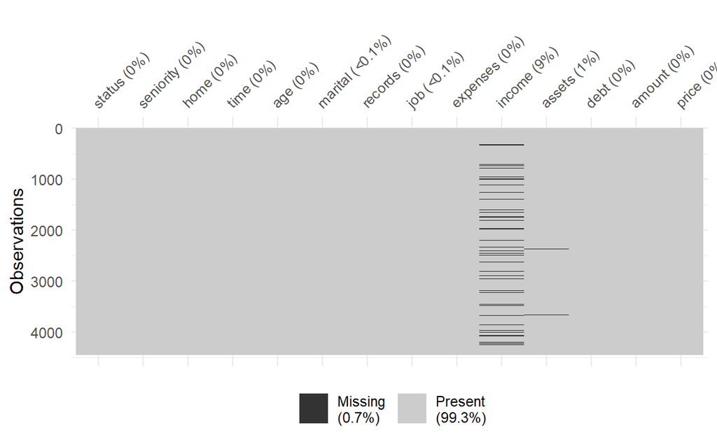

```r
vis_miss(credit_data)
```

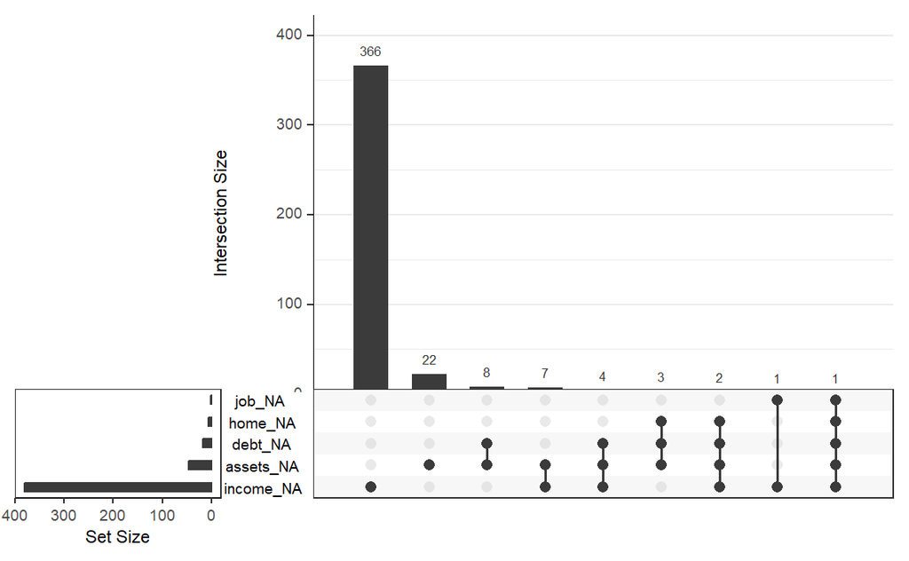

```r
gg_miss_upset(credit_data)
```

```r
credit_recipe <- credit_recipe %>%
  step_impute_mode(all_nominal()) %>%
  step_impute_mean(all_numeric())
credit_recipe
```

```
## ── Recipe ──────────────────────────────────────────────────────────────────────
```

```
## ── Inputs
```

```
## Number of variables by role
```

```
## outcome:    1
## predictor: 13
```

```
## ── Operations
```

```
## • Centering for: all_numeric()
```

```
## • Scaling for: all_numeric()
```

```
## • Box-Cox transformation on: all_numeric()
```

```
## • Mode imputation for: all_nominal()
```

```
## • Mean imputation for: all_numeric()
```

3.3.0.1.0.2.0.4 Near zero

```r
credit_recipe <- credit_recipe %>%
  step_nzv(all_predictors())
credit_recipe
```

```
## ── Recipe ──────────────────────────────────────────────────────────────────────
```

```
## ── Inputs
```

```
## Number of variables by role
```

```
## outcome:    1
## predictor: 13
```

```
## ── Operations
```

```
## • Centering for: all_numeric()
```

```
## • Scaling for: all_numeric()
```

```
## • Box-Cox transformation on: all_numeric()
```

```
## • Mode imputation for: all_nominal()
```

```
## • Mean imputation for: all_numeric()
```

```
## • Sparse, unbalanced variable filter on: all_predictors()
```

3.3.0.1.0.2.0.5 Collinearity

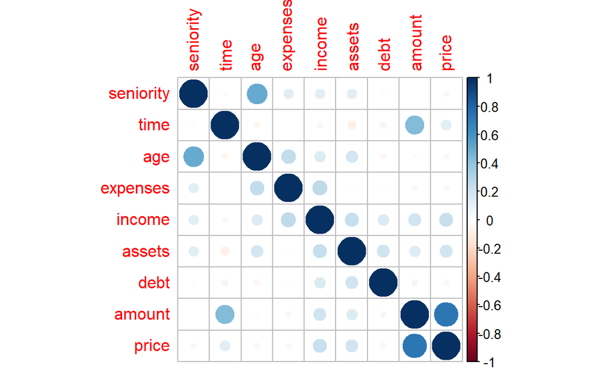

```r
credit_data %>%
  select_if(is.numeric) %>%
  cor(use = "pairwise.complete.obs") %>%
  corrplot()
```

```r
credit_recipe <- credit_recipe %>%
  step_corr(all_numeric())
credit_recipe
```

```
## ── Recipe ──────────────────────────────────────────────────────────────────────
```

```
## ── Inputs
```

```
## Number of variables by role
```

```
## outcome:    1
## predictor: 13
```

```
## ── Operations
```

```
## • Centering for: all_numeric()
```

```
## • Scaling for: all_numeric()
```

```
## • Box-Cox transformation on: all_numeric()
```

```
## • Mode imputation for: all_nominal()
```

```
## • Mean imputation for: all_numeric()
```

```
## • Sparse, unbalanced variable filter on: all_predictors()
```

```
## • Correlation filter on: all_numeric()
```

3.3.0.1.0.2.0.6 Dummy

```r
credit_recipe <- credit_recipe %>%
  step_dummy(all_nominal(), -status)
credit_recipe
```

```
## ── Recipe ──────────────────────────────────────────────────────────────────────
```

```
## ── Inputs
```

```
## Number of variables by role
```

```
## outcome:    1
## predictor: 13
```

```
## ── Operations
```

```
## • Centering for: all_numeric()
```

```
## • Scaling for: all_numeric()
```

```
## • Box-Cox transformation on: all_numeric()
```

```
## • Mode imputation for: all_nominal()
```

```
## • Mean imputation for: all_numeric()
```

```
## • Sparse, unbalanced variable filter on: all_predictors()
```

```
## • Correlation filter on: all_numeric()
```

```
## • Dummy variables from: all_nominal() -status
```

```r
tidy(credit_recipe)
```

```
## # A tibble: 8 × 6
##   number operation type        trained skip  id
##    <int> <chr>     <chr>       <lgl>   <lgl> <chr>
## 1      1 step      center      FALSE   FALSE center_NyB8z
## 2      2 step      scale       FALSE   FALSE scale_a5XZG
## 3      3 step      BoxCox      FALSE   FALSE BoxCox_FRqy8
## 4      4 step      impute_mode FALSE   FALSE impute_mode_px8ew
## 5      5 step      impute_mean FALSE   FALSE impute_mean_RyqGB
## 6      6 step      nzv         FALSE   FALSE nzv_j2cCA
## 7      7 step      corr        FALSE   FALSE corr_LX33P
## 8      8 step      dummy       FALSE   FALSE dummy_1OY8d
```

```r
tidy(credit_recipe, n = 1)
```

```
## # A tibble: 1 × 3
##   terms         value id
##   <chr>         <dbl> <chr>
## 1 all_numeric()    NA center_NyB8z
```

#### 3.3.0.2 Prep recipe

```r
credit_recipe <- credit_recipe %>%
  prep(data = credit_data)
credit_recipe
```

```
## ── Recipe ──────────────────────────────────────────────────────────────────────
```

```
## ── Inputs
```

```
## Number of variables by role
```

```
## outcome:    1
## predictor: 13
```

```
## ── Training information
```

```
## Training data contained 4454 data points and 415 incomplete rows.
```

```
## ── Operations
```

```
## • Centering for: seniority, time, age, expenses, income, ... | Trained
```

```
## • Scaling for: seniority, time, age, expenses, income, assets, ... | Trained
```

```
## • Box-Cox transformation on: <none> | Trained
```

```
## • Mode imputation for: home, marital, records, job, status | Trained
```

```
## • Mean imputation for: seniority, time, age, expenses, income, ... | Trained
```

```
## • Sparse, unbalanced variable filter removed: debt | Trained
```

```
## • Correlation filter on: <none> | Trained
```

```
## • Dummy variables from: home, marital, records, job | Trained
```

```r
tidy(credit_recipe)
```

```
## # A tibble: 8 × 6
##   number operation type        trained skip  id
##    <int> <chr>     <chr>       <lgl>   <lgl> <chr>
## 1      1 step      center      TRUE    FALSE center_NyB8z
## 2      2 step      scale       TRUE    FALSE scale_a5XZG
## 3      3 step      BoxCox      TRUE    FALSE BoxCox_FRqy8
## 4      4 step      impute_mode TRUE    FALSE impute_mode_px8ew
## 5      5 step      impute_mean TRUE    FALSE impute_mean_RyqGB
## 6      6 step      nzv         TRUE    FALSE nzv_j2cCA
## 7      7 step      corr        TRUE    FALSE corr_LX33P
## 8      8 step      dummy       TRUE    FALSE dummy_1OY8d
```

```r
tidy(credit_recipe, n = 1)
```

```
## # A tibble: 9 × 3
##   terms       value id
##   <chr>       <dbl> <chr>
## 1 seniority    7.99 center_NyB8z
## 2 time        46.4  center_NyB8z
## 3 age         37.1  center_NyB8z
## 4 expenses    55.6  center_NyB8z
## 5 income     142.   center_NyB8z
## 6 assets    5404.   center_NyB8z
## 7 debt       343.   center_NyB8z
## 8 amount    1039.   center_NyB8z
## 9 price     1463.   center_NyB8z
```

## 3.4 Get data

#### 3.4.0.1 Juice

```r
credit_recipe %>% juice()
```

```
## # A tibble: 4,454 × 22
##    seniority   time     age expenses income assets  amount    price status
##        <dbl>  <dbl>   <dbl>    <dbl>  <dbl>  <dbl>   <dbl>    <dbl> <fct>
##  1     0.124  0.925 -0.645     0.893 -0.157 -0.467 -0.503  -0.982   good
##  2     1.10   0.925  1.90     -0.388 -0.132 -0.467 -0.0820  0.311   good
##  3     0.246 -0.712  0.812     1.76   0.722 -0.208  2.03    2.42    bad
##  4    -0.977  0.925 -1.19      0.381  0.499 -0.251 -0.293  -0.219   good
##  5    -0.977 -0.712 -1.01     -0.491 -0.430 -0.467 -1.54   -0.880   good
##  6    -0.855  0.925 -0.0984    0.995  0.896 -0.164 -0.820   0.290   good
##  7     2.57   0.925  0.630     0.995 -0.207  0.397  1.18    0.537   good
##  8     0.124 -2.35  -0.918    -1.05  -0.764 -0.467 -1.77   -0.589   good
##  9    -0.977  0.925 -0.463     1.76  -0.430  0.829  0.339   0.787   good
## 10    -0.977  0.107  0.357     1.76  -0.764 -0.467  0.339   0.00831 bad
## # ℹ 4,444 more rows
## # ℹ 13 more variables: home_other <dbl>, home_owner <dbl>, home_parents <dbl>,
## #   home_priv <dbl>, home_rent <dbl>, marital_married <dbl>,
## #   marital_separated <dbl>, marital_single <dbl>, marital_widow <dbl>,
## #   records_yes <dbl>, job_freelance <dbl>, job_others <dbl>, job_partime <dbl>
```

#### 3.4.0.2 Bake

```r
credit_recipe %>% bake(credit_data)
```

```
## # A tibble: 4,454 × 22
##    seniority   time     age expenses income assets  amount    price status
##        <dbl>  <dbl>   <dbl>    <dbl>  <dbl>  <dbl>   <dbl>    <dbl> <fct>
##  1     0.124  0.925 -0.645     0.893 -0.157 -0.467 -0.503  -0.982   good
##  2     1.10   0.925  1.90     -0.388 -0.132 -0.467 -0.0820  0.311   good
##  3     0.246 -0.712  0.812     1.76   0.722 -0.208  2.03    2.42    bad
##  4    -0.977  0.925 -1.19      0.381  0.499 -0.251 -0.293  -0.219   good
##  5    -0.977 -0.712 -1.01     -0.491 -0.430 -0.467 -1.54   -0.880   good
##  6    -0.855  0.925 -0.0984    0.995  0.896 -0.164 -0.820   0.290   good
##  7     2.57   0.925  0.630     0.995 -0.207  0.397  1.18    0.537   good
##  8     0.124 -2.35  -0.918    -1.05  -0.764 -0.467 -1.77   -0.589   good
##  9    -0.977  0.925 -0.463     1.76  -0.430  0.829  0.339   0.787   good
## 10    -0.977  0.107  0.357     1.76  -0.764 -0.467  0.339   0.00831 bad
## # ℹ 4,444 more rows
## # ℹ 13 more variables: home_other <dbl>, home_owner <dbl>, home_parents <dbl>,
## #   home_priv <dbl>, home_rent <dbl>, marital_married <dbl>,
## #   marital_separated <dbl>, marital_single <dbl>, marital_widow <dbl>,
## #   records_yes <dbl>, job_freelance <dbl>, job_others <dbl>, job_partime <dbl>
```

# 4 DS_CS04_Cross_Validation_Titanic

## 4.1 Load data

```r
data("titanic_train", package = "titanic")
titanic <- as_tibble(titanic_train)
titanic
```

```
## # A tibble: 891 × 12
##    PassengerId Survived Pclass Name   Sex     Age SibSp Parch Ticket  Fare Cabin
##          <int>    <int>  <int> <chr>  <chr> <dbl> <int> <int> <chr>  <dbl> <chr>
##  1           1        0      3 Braun… male     22     1     0 A/5 2…  7.25 ""
##  2           2        1      1 Cumin… fema…    38     1     0 PC 17… 71.3  "C85"
##  3           3        1      3 Heikk… fema…    26     0     0 STON/…  7.92 ""
##  4           4        1      1 Futre… fema…    35     1     0 113803 53.1  "C12…
##  5           5        0      3 Allen… male     35     0     0 373450  8.05 ""
##  6           6        0      3 Moran… male     NA     0     0 330877  8.46 ""
##  7           7        0      1 McCar… male     54     0     0 17463  51.9  "E46"
##  8           8        0      3 Palss… male      2     3     1 349909 21.1  ""
##  9           9        1      3 Johns… fema…    27     0     2 347742 11.1  ""
## 10          10        1      2 Nasse… fema…    14     1     0 237736 30.1  ""
## # ℹ 881 more rows
## # ℹ 1 more variable: Embarked <chr>
```

## 4.2 Clean names

```r
titanic <- titanic %>% clean_names()
titanic
```

```
## # A tibble: 891 × 12
##    passenger_id survived pclass name       sex     age sib_sp parch ticket  fare
##           <int>    <int>  <int> <chr>      <chr> <dbl>  <int> <int> <chr>  <dbl>
##  1            1        0      3 Braund, M… male     22      1     0 A/5 2…  7.25
##  2            2        1      1 Cumings, … fema…    38      1     0 PC 17… 71.3
##  3            3        1      3 Heikkinen… fema…    26      0     0 STON/…  7.92
##  4            4        1      1 Futrelle,… fema…    35      1     0 113803 53.1
##  5            5        0      3 Allen, Mr… male     35      0     0 373450  8.05
##  6            6        0      3 Moran, Mr… male     NA      0     0 330877  8.46
##  7            7        0      1 McCarthy,… male     54      0     0 17463  51.9
##  8            8        0      3 Palsson, … male      2      3     1 349909 21.1
##  9            9        1      3 Johnson, … fema…    27      0     2 347742 11.1
## 10           10        1      2 Nasser, M… fema…    14      1     0 237736 30.1
## # ℹ 881 more rows
## # ℹ 2 more variables: cabin <chr>, embarked <chr>
```

## 4.3 Convert survived to factor

```r
titanic <- titanic %>%
  mutate_all(factor)
titanic
```

```
## # A tibble: 891 × 12
##    passenger_id survived pclass name       sex   age   sib_sp parch ticket fare
##    <fct>        <fct>    <fct>  <fct>      <fct> <fct> <fct>  <fct> <fct>  <fct>
##  1 1            0        3      Braund, M… male  22    1      0     A/5 2… 7.25
##  2 2            1        1      Cumings, … fema… 38    1      0     PC 17… 71.2…
##  3 3            1        3      Heikkinen… fema… 26    0      0     STON/… 7.925
##  4 4            1        1      Futrelle,… fema… 35    1      0     113803 53.1
##  5 5            0        3      Allen, Mr… male  35    0      0     373450 8.05
##  6 6            0        3      Moran, Mr… male  <NA>  0      0     330877 8.45…
##  7 7            0        1      McCarthy,… male  54    0      0     17463  51.8…
##  8 8            0        3      Palsson, … male  2     3      1     349909 21.0…
##  9 9            1        3      Johnson, … fema… 27    0      2     347742 11.1…
## 10 10           1        2      Nasser, M… fema… 14    1      0     237736 30.0…
## # ℹ 881 more rows
## # ℹ 2 more variables: cabin <fct>, embarked <fct>
```

## 4.4 Split into training and test

```r
titanic_split <- initial_split(titanic, strata = survived)
titanic_train <- training(titanic_split)
titanic_test <- testing(titanic_split)
```

```r
titanic_train
```

```
## # A tibble: 667 × 12
##    passenger_id survived pclass name       sex   age   sib_sp parch ticket fare
##    <fct>        <fct>    <fct>  <fct>      <fct> <fct> <fct>  <fct> <fct>  <fct>
##  1 6            0        3      Moran, Mr… male  <NA>  0      0     330877 8.45…
##  2 7            0        1      McCarthy,… male  54    0      0     17463  51.8…
##  3 8            0        3      Palsson, … male  2     3      1     349909 21.0…
##  4 13           0        3      Saunderco… male  20    0      0     A/5. … 8.05
##  5 15           0        3      Vestrom, … fema… 14    0      0     350406 7.85…
##  6 17           0        3      Rice, Mas… male  2     4      1     382652 29.1…
##  7 21           0        2      Fynney, M… male  35    0      0     239865 26
##  8 25           0        3      Palsson, … fema… 8     3      1     349909 21.0…
##  9 28           0        1      Fortune, … male  19    3      2     19950  263
## 10 31           0        1      Uruchurtu… male  40    0      0     PC 17… 27.7…
## # ℹ 657 more rows
## # ℹ 2 more variables: cabin <fct>, embarked <fct>
```

```r
titanic_test
```

```
## # A tibble: 224 × 12
##    passenger_id survived pclass name       sex   age   sib_sp parch ticket fare
##    <fct>        <fct>    <fct>  <fct>      <fct> <fct> <fct>  <fct> <fct>  <fct>
##  1 1            0        3      "Braund, … male  22    1      0     A/5 2… 7.25
##  2 3            1        3      "Heikkine… fema… 26    0      0     STON/… 7.925
##  3 4            1        1      "Futrelle… fema… 35    1      0     113803 53.1
##  4 5            0        3      "Allen, M… male  35    0      0     373450 8.05
##  5 9            1        3      "Johnson,… fema… 27    0      2     347742 11.1…
##  6 14           0        3      "Andersso… male  39    1      5     347082 31.2…
##  7 19           0        3      "Vander P… fema… 31    1      0     345763 18
##  8 23           1        3      "McGowan,… fema… 15    0      0     330923 8.02…
##  9 24           1        1      "Sloper, … male  28    0      0     113788 35.5
## 10 26           1        3      "Asplund,… fema… 38    1      5     347077 31.3…
## # ℹ 214 more rows
## # ℹ 2 more variables: cabin <fct>, embarked <fct>
```

## 4.5 Get CV of training

```r
titanic_cv <- vfold_cv(titanic_train, v = 5, strata = survived)
titanic_cv
```

```
## #  5-fold cross-validation using stratification
## # A tibble: 5 × 2
##   splits            id
##   <list>            <chr>
## 1 <split [532/135]> Fold1
## 2 <split [534/133]> Fold2
## 3 <split [534/133]> Fold3
## 4 <split [534/133]> Fold4
## 5 <split [534/133]> Fold5
```

## 4.6 Set up workflow

#### 4.6.0.1 Recipe

```r
titanic_recipe <-
  recipe(survived ~ sex + pclass, data = titanic_train) %>%
  step_dummy(all_predictors()) %>%
  step_interact(terms = ~starts_with("sex"):starts_with("pclass"))
```

```r
titanic_recipe %>% prep() %>% juice()
```

```
## # A tibble: 667 × 6
##    survived sex_male pclass_X2 pclass_X3 sex_male_x_pclass_X2
##    <fct>       <dbl>     <dbl>     <dbl>                <dbl>
##  1 0               1         0         1                    0
##  2 0               1         0         0                    0
##  3 0               1         0         1                    0
##  4 0               1         0         1                    0
##  5 0               0         0         1                    0
##  6 0               1         0         1                    0
##  7 0               1         1         0                    1
##  8 0               0         0         1                    0
##  9 0               1         0         0                    0
## 10 0               1         0         0                    0
## # ℹ 657 more rows
## # ℹ 1 more variable: sex_male_x_pclass_X3 <dbl>
```

#### 4.6.0.2 Model

```r
titanic_model <- logistic_reg() %>% set_engine("glm")
```

```r
titanic_wf <- workflow() %>%
  add_recipe(titanic_recipe) %>%
  add_model(titanic_model)
titanic_wf
```

```
## ══ Workflow ════════════════════════════════════════════════════════════════════
## Preprocessor: Recipe
## Model: logistic_reg()
##
## ── Preprocessor ────────────────────────────────────────────────────────────────
## 2 Recipe Steps
##
## • step_dummy()
## • step_interact()
##
## ── Model ───────────────────────────────────────────────────────────────────────
## Logistic Regression Model Specification (classification)
##
## Computational engine: glm
```

```r
titanic_fit <- fit(titanic_wf, titanic_train)
titanic_fit %>% tidy()
```

```
## # A tibble: 6 × 5
##   term                 estimate std.error statistic       p.value
##   <chr>                   <dbl>     <dbl>     <dbl>         <dbl>
## 1 (Intercept)             3.06      0.591     5.18  0.000000221
## 2 sex_male               -3.62      0.628    -5.76  0.00000000833
## 3 pclass_X2              -0.439     0.786    -0.559 0.576
## 4 pclass_X3              -3.17      0.621    -5.10  0.000000332
## 5 sex_male_x_pclass_X2   -0.586     0.865    -0.677 0.498
## 6 sex_male_x_pclass_X3    1.95      0.680     2.87  0.00408
```

## 4.7 Fit CV

```r
titanic_fits <- fit_resamples(
  titanic_wf,
  resamples = titanic_cv,
  control = control_resamples(save_pred = TRUE)
)
titanic_fits
```

```
## # Resampling results
## # 5-fold cross-validation using stratification
## # A tibble: 5 × 5
##   splits            id    .metrics         .notes           .predictions
##   <list>            <chr> <list>           <list>           <list>
## 1 <split [532/135]> Fold1 <tibble [3 × 4]> <tibble [0 × 3]> <tibble [135 × 6]>
## 2 <split [534/133]> Fold2 <tibble [3 × 4]> <tibble [0 × 3]> <tibble [133 × 6]>
## 3 <split [534/133]> Fold3 <tibble [3 × 4]> <tibble [0 × 3]> <tibble [133 × 6]>
## 4 <split [534/133]> Fold4 <tibble [3 × 4]> <tibble [0 × 3]> <tibble [133 × 6]>
## 5 <split [534/133]> Fold5 <tibble [3 × 4]> <tibble [0 × 3]> <tibble [133 × 6]>
```

## 4.8 Get metrics

```r
titanic_fits %>% collect_metrics()
```

```
## # A tibble: 3 × 6
##   .metric     .estimator  mean     n std_err .config
##   <chr>       <chr>      <dbl> <int>   <dbl> <chr>
## 1 accuracy    binary     0.784     5 0.0145  Preprocessor1_Model1
## 2 brier_class binary     0.151     5 0.00612 Preprocessor1_Model1
## 3 roc_auc     binary     0.811     5 0.0125  Preprocessor1_Model1
```

## 4.9 ROC curves

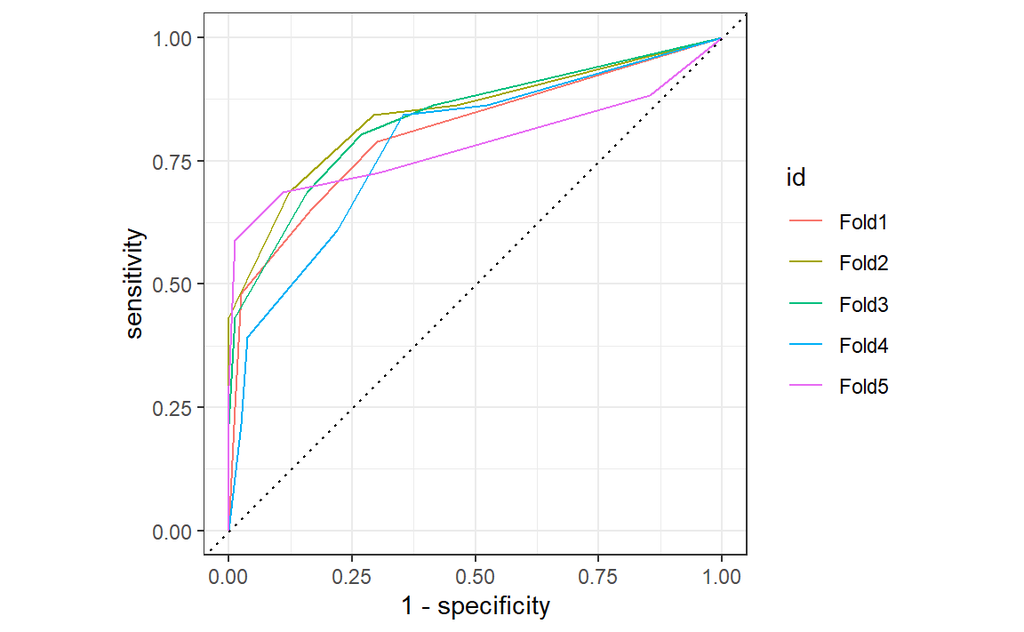

```r
CV_ROC <-
  titanic_fits %>%
  collect_predictions() %>%
  group_by(id) %>%
  roc_curve(truth = survived, .pred_1, event_level = "second")
CV_ROC %>% autoplot()
```

## 4.10 Compare to test

```r
titanic_test %>%
  add_column(
    predict(titanic_fit, new_data = titanic_test, type = "prob")
  ) %>%
  roc_auc(truth = survived, .pred_1, event_level = "second")
```

```
## # A tibble: 1 × 3
##   .metric .estimator .estimate
##   <chr>   <chr>          <dbl>
## 1 roc_auc binary         0.868
```

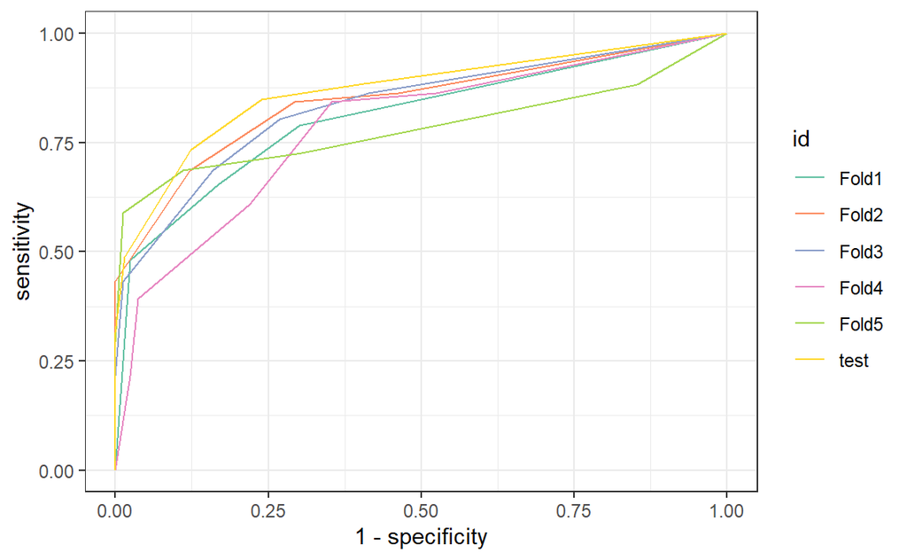

```r
test_ROC <- titanic_test %>%
  add_column(
    predict(titanic_fit, new_data = titanic_test, type = "prob")
  ) %>%
  roc_curve(truth = survived, .pred_1, event_level = "second") %>%
  add_column(id = "test")
bind_rows(CV_ROC, test_ROC) %>%
  ggplot(aes(1 - specificity, sensitivity, col = id)) + geom_path() +
  scale_color_brewer(palette = "Set2")
```

# 5 DS_CS05_Ridge_Regression_The_Office

## 5.1 Read in data

```r
data("theoffice", package = "schrute")
office <- theoffice
office
```

```
## # A tibble: 55,130 × 12
##    index season episode episode_name director   writer           character text
##    <int>  <int>   <int> <chr>        <chr>      <chr>            <chr>     <chr>
##  1     1      1       1 Pilot        Ken Kwapis Ricky Gervais;S… Michael   All …
##  2     2      1       1 Pilot        Ken Kwapis Ricky Gervais;S… Jim       Oh, …
##  3     3      1       1 Pilot        Ken Kwapis Ricky Gervais;S… Michael   So y…
##  4     4      1       1 Pilot        Ken Kwapis Ricky Gervais;S… Jim       Actu…
##  5     5      1       1 Pilot        Ken Kwapis Ricky Gervais;S… Michael   All …
##  6     6      1       1 Pilot        Ken Kwapis Ricky Gervais;S… Michael   Yes,…
##  7     7      1       1 Pilot        Ken Kwapis Ricky Gervais;S… Michael   I've…
##  8     8      1       1 Pilot        Ken Kwapis Ricky Gervais;S… Pam       Well…
##  9     9      1       1 Pilot        Ken Kwapis Ricky Gervais;S… Michael   If y…
## 10    10      1       1 Pilot        Ken Kwapis Ricky Gervais;S… Pam       What?
## # ℹ 55,120 more rows
## # ℹ 4 more variables: text_w_direction <chr>, imdb_rating <dbl>,
## #   total_votes <int>, air_date <chr>
```

So each row is a line from the script, we also have info about season, episode etc.

Want to predict rating from how much each character speaks.

## 5.2 Characters

How many characters?

```r
length(unique(office$character))
```

```
## [1] 773
```

Too many, so we will collapse down

```r
office <-
  office %>%
  mutate(
    character = fct_lump_n(character, 20)
  )
unique(office$character)
```

```
##  [1] Michael  Jim      Pam      Dwight   Jan      Other    Phyllis  Stanley
##  [9] Oscar    Angela   Kevin    Ryan     Toby     Kelly    Meredith Darryl
## [17] Andy     Holly    Erin     Gabe     Nellie
## 21 Levels: Andy Angela Darryl Dwight Erin Gabe Holly Jan Jim Kelly ... Other
```

## 5.3 Cleaning

First count the number of lines for each character.

```r
office_long <-
  office %>%
  group_by(season, episode, character) %>%
  summarise(
    n_lines = n(),
    rating = mean(imdb_rating)
  )
office_long
```

```
## # A tibble: 2,719 × 5
## # Groups:   season, episode [186]
##    season episode character n_lines rating
##     <int>   <int> <fct>       <int>  <dbl>
##  1      1       1 Angela          1    7.6
##  2      1       1 Dwight         29    7.6
##  3      1       1 Jan            12    7.6
##  4      1       1 Jim            36    7.6
##  5      1       1 Kevin           1    7.6
##  6      1       1 Michael        81    7.6
##  7      1       1 Oscar           3    7.6
##  8      1       1 Pam            41    7.6
##  9      1       1 Phyllis         2    7.6
## 10      1       1 Ryan            8    7.6
## # ℹ 2,709 more rows
```

Now convert to wide form

```r
office_wide <-
  office_long %>%
  pivot_wider(
    names_from = character,
    values_from = n_lines,
    values_fill = 0
  )
office_wide
```

```
## # A tibble: 186 × 24
## # Groups:   season, episode [186]
##    season episode rating Angela Dwight   Jan   Jim Kevin Michael Oscar   Pam
##     <int>   <int>  <dbl>  <int>  <int> <int> <int> <int>   <int> <int> <int>
##  1      1       1    7.6      1     29    12    36     1      81     3    41
##  2      1       2    8.3      4     17     0    25     8      75    13    12
##  3      1       3    7.9      5     62    18    42     6      56     9    32
##  4      1       4    8.1      7     47     0    49     3      68    14    22
##  5      1       5    8.4      3     25     0    21     1     104     2    14
##  6      1       6    7.8      3     28     8    55     5     106     1    45
##  7      2       1    8.7      1     32     9    32     1      96     2    41
##  8      2       2    8.2      2     11    11    16     6     100     0    27
##  9      2       3    8.4      6     55     0    55     9      83    10    33
## 10      2       4    8.4     17     65     0    51     5      69     4    22
## # ℹ 176 more rows
## # ℹ 13 more variables: Phyllis <int>, Ryan <int>, Stanley <int>, Other <int>,
## #   Kelly <int>, Toby <int>, Meredith <int>, Darryl <int>, Andy <int>,
## #   Holly <int>, Erin <int>, Gabe <int>, Nellie <int>
```

## 5.4 Split

```r
office_split <- initial_split(office_wide, strata = rating)
office_train <- training(office_split)
office_test <- testing(office_split)
```

## 5.5 Preprocessing

```r
office_recipe <-
  recipe(rating ~ ., data = office_train)
office_recipe
```

```
## ── Recipe ──────────────────────────────────────────────────────────────────────
```

```
## ── Inputs
```

```
## Number of variables by role
```

```
## outcome:    1
## predictor: 23
```

Set ID columns

```r
office_recipe <-
  office_recipe %>%
  update_role(season,episode, new_role = "ID")
office_recipe
```

```
## ── Recipe ──────────────────────────────────────────────────────────────────────
```

```
## ── Inputs
```

```
## Number of variables by role
```

```
## outcome:    1
## predictor: 21
## ID:         2
```

Scale and center

```r
office_recipe <-
  office_recipe %>%
  step_center(all_predictors()) %>%
  step_scale(all_predictors())
```

Check

```r
office_recipe %>% prep() %>% juice()
```

```
## # A tibble: 137 × 24
##    season episode Angela  Dwight    Jan     Jim   Kevin Michael  Oscar     Pam
##     <int>   <int>  <dbl>   <dbl>  <dbl>   <dbl>   <dbl>   <dbl>  <dbl>   <dbl>
##  1      1       1 -0.813 -0.400   0.583  0.0768 -1.13     0.419 -0.586  0.734
##  2      1       6 -0.582 -0.453   0.261  1.06   -0.520    1.02  -0.877  0.956
##  3      2      14 -0.697 -0.611  -0.383 -0.390  -0.215    0.897 -0.296  0.0118
##  4      6       6 -0.929  0.709  -0.383 -1.06    1.31     1.40   1.59  -1.27
##  5      6      14 -0.697 -1.03   -0.383 -1.79   -0.979   -0.467 -1.02  -1.27
##  6      6      15 -0.697 -1.46   -0.383 -0.442  -1.13     0.443 -0.296 -0.155
##  7      6      19 -0.582 -0.400  -0.383  0.284  -0.826   -0.275 -0.441 -1.49
##  8      6      20 -0.235  0.340  -0.383  0.855  -0.0624   0.514 -0.877 -1.38
##  9      6      22 -0.350 -1.03   -0.383 -1.38    1.77    -0.419 -0.151  0.0118
## 10      6      25  1.04  -0.0301 -0.383 -0.701  -0.368    0.443 -0.586  0.123
## # ℹ 127 more rows
## # ℹ 14 more variables: Phyllis <dbl>, Ryan <dbl>, Stanley <dbl>, Other <dbl>,
## #   Kelly <dbl>, Toby <dbl>, Meredith <dbl>, Darryl <dbl>, Andy <dbl>,
## #   Holly <dbl>, Erin <dbl>, Gabe <dbl>, Nellie <dbl>, rating <dbl>
```

```r
office_recipe %>% prep() %>% juice() %>% select(rating)
```

```
## # A tibble: 137 × 1
##    rating
##     <dbl>
##  1    7.6
##  2    7.8
##  3    7.9
##  4    7.7
##  5    6.8
##  6    7.8
##  7    7.8
##  8    7.9
##  9    7.9
## 10    7.9
## # ℹ 127 more rows
```

## 5.6 Fit ridge regression

#### 5.6.0.1 Set model

```r
office_model <-
  linear_reg(mixture = 0, penalty = 0.1) %>%
  set_engine("glmnet")
```

Note still uses lots of lambdas - see fit. Penalty only used for prediction.

#### 5.6.0.2 Create workflow

```r
office_wf <-
  workflow() %>%
  add_recipe(office_recipe) %>%
  add_model(office_model)
office_wf
```

```
## ══ Workflow ════════════════════════════════════════════════════════════════════
## Preprocessor: Recipe
## Model: linear_reg()
##
## ── Preprocessor ────────────────────────────────────────────────────────────────
## 2 Recipe Steps
##
## • step_center()
## • step_scale()
##
## ── Model ───────────────────────────────────────────────────────────────────────
## Linear Regression Model Specification (regression)
##
## Main Arguments:
##   penalty = 0.1
##   mixture = 0
##
## Computational engine: glmnet
```

#### 5.6.0.3 Fit workflow

```r
office_ridge <-
  office_wf %>%
  fit(office_train)
office_ridge
```

```
## ══ Workflow [trained] ══════════════════════════════════════════════════════════
## Preprocessor: Recipe
## Model: linear_reg()
##
## ── Preprocessor ────────────────────────────────────────────────────────────────
## 2 Recipe Steps
##
## • step_center()
## • step_scale()
##
## ── Model ───────────────────────────────────────────────────────────────────────
##
## Call:  glmnet::glmnet(x = maybe_matrix(x), y = y, family = "gaussian",      alpha = ~0)
##
##     Df  %Dev  Lambda
```

[output cut: 49 more lines]

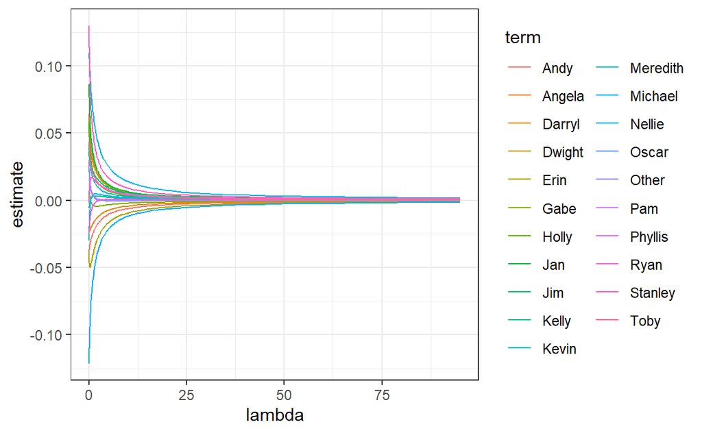

```r
p <- office_ridge %>%
  extract_fit_parsnip() %>%
  .$fit  %>%
  tidy() %>%
  filter(
    term != "(Intercept)",
    lambda < 100
  ) %>%
  ggplot(aes(lambda, estimate, col = term)) +
  geom_line()
p
```

```r
ggplotly(p)
```

[interactive chart not shown]

## 5.7 Predict

#### 5.7.0.1 Train RMSE

```r
office_train %>%
  add_column(
    predict(office_ridge, new_data = office_train)
  ) %>%
  ungroup() %>%
  rmse(rating, .pred)
```

```
## # A tibble: 1 × 3
##   .metric .estimator .estimate
##   <chr>   <chr>          <dbl>
## 1 rmse    standard       0.404
```

#### 5.7.0.2 Test RMSE

```r
office_test %>%
  add_column(
    predict(office_ridge, new_data = office_test)
  ) %>%
  ungroup() %>%
  rmse(rating, .pred)
```

```
## # A tibble: 1 × 3
##   .metric .estimator .estimate
##   <chr>   <chr>          <dbl>
## 1 rmse    standard       0.432
```

## 5.8 VIP

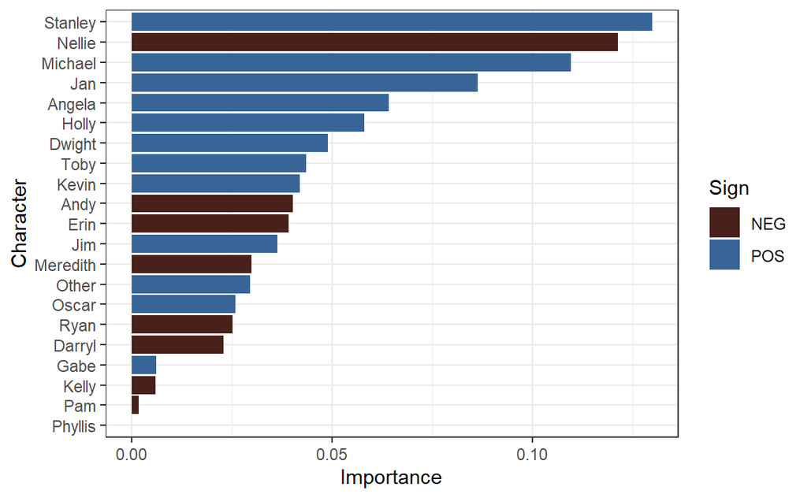

```r
office_ridge %>%
  pull_workflow_fit() %>%
  vi() %>%
  ggplot(aes(Importance, fct_reorder(Variable, Importance), fill = Sign)) +
  geom_col() +
  labs(y = "Character") +
  scale_fill_paletteer_d("dutchmasters::milkmaid")
```

# 6 DS_CS06_Lasso_Hitters

## 6.1 Get the Data

```r
data("Hitters", package = "ISLR")
hitters <- as_tibble(Hitters)
hitters
```

```
## # A tibble: 322 × 20
##    AtBat  Hits HmRun  Runs   RBI Walks Years CAtBat CHits CHmRun CRuns  CRBI
##    <int> <int> <int> <int> <int> <int> <int>  <int> <int>  <int> <int> <int>
##  1   293    66     1    30    29    14     1    293    66      1    30    29
##  2   315    81     7    24    38    39    14   3449   835     69   321   414
##  3   479   130    18    66    72    76     3   1624   457     63   224   266
##  4   496   141    20    65    78    37    11   5628  1575    225   828   838
##  5   321    87    10    39    42    30     2    396   101     12    48    46
##  6   594   169     4    74    51    35    11   4408  1133     19   501   336
##  7   185    37     1    23     8    21     2    214    42      1    30     9
##  8   298    73     0    24    24     7     3    509   108      0    41    37
##  9   323    81     6    26    32     8     2    341    86      6    32    34
## 10   401    92    17    49    66    65    13   5206  1332    253   784   890
## # ℹ 312 more rows
## # ℹ 8 more variables: CWalks <int>, League <fct>, Division <fct>,
## #   PutOuts <int>, Assists <int>, Errors <int>, Salary <dbl>, NewLeague <fct>
```

## 6.2 Cleaning

#### 6.2.0.1 Clean Variable Names

```r
hitters %<>% janitor::clean_names()
hitters
```

```
## # A tibble: 322 × 20
##    at_bat  hits hm_run  runs   rbi walks years c_at_bat c_hits c_hm_run c_runs
##     <int> <int>  <int> <int> <int> <int> <int>    <int>  <int>    <int>  <int>
##  1    293    66      1    30    29    14     1      293     66        1     30
##  2    315    81      7    24    38    39    14     3449    835       69    321
##  3    479   130     18    66    72    76     3     1624    457       63    224
##  4    496   141     20    65    78    37    11     5628   1575      225    828
##  5    321    87     10    39    42    30     2      396    101       12     48
##  6    594   169      4    74    51    35    11     4408   1133       19    501
##  7    185    37      1    23     8    21     2      214     42        1     30
##  8    298    73      0    24    24     7     3      509    108        0     41
##  9    323    81      6    26    32     8     2      341     86        6     32
## 10    401    92     17    49    66    65    13     5206   1332      253    784
## # ℹ 312 more rows
## # ℹ 9 more variables: crbi <int>, c_walks <int>, league <fct>, division <fct>,
## #   put_outs <int>, assists <int>, errors <int>, salary <dbl>, new_league <fct>
```

#### 6.2.0.2 Remove NA Values

```r
hitters %<>% drop_na()
hitters
```

```
## # A tibble: 263 × 20
##    at_bat  hits hm_run  runs   rbi walks years c_at_bat c_hits c_hm_run c_runs
##     <int> <int>  <int> <int> <int> <int> <int>    <int>  <int>    <int>  <int>
##  1    315    81      7    24    38    39    14     3449    835       69    321
##  2    479   130     18    66    72    76     3     1624    457       63    224
##  3    496   141     20    65    78    37    11     5628   1575      225    828
##  4    321    87     10    39    42    30     2      396    101       12     48
##  5    594   169      4    74    51    35    11     4408   1133       19    501
##  6    185    37      1    23     8    21     2      214     42        1     30
##  7    298    73      0    24    24     7     3      509    108        0     41
##  8    323    81      6    26    32     8     2      341     86        6     32
##  9    401    92     17    49    66    65    13     5206   1332      253    784
## 10    574   159     21   107    75    59    10     4631   1300       90    702
## # ℹ 253 more rows
## # ℹ 9 more variables: crbi <int>, c_walks <int>, league <fct>, division <fct>,
## #   put_outs <int>, assists <int>, errors <int>, salary <dbl>, new_league <fct>
```

#### 6.2.0.3 Create Train and Test Splits

```r
hitters_split <- initial_split(hitters, strata = salary)
hitters_train <- training(hitters_split)
hitters_test <- testing(hitters_split)
```

##Workflow

#### 6.2.0.4 Recipe

```r
hitters_recipe <- recipe(salary ~ ., data = hitters) %>%
  step_normalize(all_numeric_predictors()) %>%
  step_dummy(all_nominal_predictors())
hitters_recipe %>% prep() %>% bake(new_data = NULL)
```

```
## # A tibble: 263 × 20
##     at_bat   hits hm_run   runs     rbi   walks  years c_at_bat c_hits c_hm_run
##      <dbl>  <dbl>  <dbl>  <dbl>   <dbl>   <dbl>  <dbl>    <dbl>  <dbl>    <dbl>
##  1 -0.602  -0.595 -0.528 -1.20  -0.521  -0.0973  1.40     0.346  0.174 -0.00291
##  2  0.512   0.491  0.729  0.441  0.793   1.61   -0.899   -0.452 -0.409 -0.0759
##  3  0.627   0.735  0.957  0.402  1.02   -0.189   0.769    1.30   1.32   1.89
##  4 -0.561  -0.462 -0.185 -0.616 -0.367  -0.512  -1.11    -0.989 -0.958 -0.696
##  5  1.29    1.36  -0.870  0.754 -0.0188 -0.282   0.769    0.766  0.634 -0.611
##  6 -1.48   -1.57  -1.21  -1.24  -1.68   -0.926  -1.11    -1.07  -1.05  -0.830
##  7 -0.717  -0.772 -1.33  -1.20  -1.06   -1.57   -0.899   -0.940 -0.948 -0.842
##  8 -0.547  -0.595 -0.642 -1.13  -0.753  -1.52   -1.11    -1.01  -0.981 -0.769
##  9 -0.0179 -0.351  0.614 -0.225  0.561   1.10    1.19     1.11   0.941  2.24
## 10  1.16    1.13   1.07   2.05   0.908   0.824   0.561    0.863  0.891  0.253
## # ℹ 253 more rows
## # ℹ 10 more variables: c_runs <dbl>, crbi <dbl>, c_walks <dbl>, put_outs <dbl>,
## #   assists <dbl>, errors <dbl>, salary <dbl>, league_N <dbl>,
## #   division_W <dbl>, new_league_N <dbl>
```

```r
hitters_recipe %>% prep() %>% bake(new_data = NULL) %>% pull(salary)
```

```
##   [1]  475.000  480.000  500.000   91.500  750.000   70.000  100.000   75.000
##   [9] 1100.000  517.143  512.500  550.000  700.000  240.000  775.000  175.000
##  [17]  135.000  100.000  115.000  600.000  776.667  765.000  708.333  750.000
##  [25]  625.000  900.000  110.000  612.500  300.000  850.000   90.000   67.500
##  [33]  180.000  305.000  215.000  247.500  815.000  875.000   70.000 1200.000
##  [41]  675.000  415.000  340.000  416.667 1350.000   90.000  275.000  230.000
##  [49]  225.000  950.000   75.000  105.000  320.000  850.000  535.000  933.333
##  [57]  850.000  210.000  325.000  275.000  450.000 1975.000 1900.000  600.000
##  [65] 1041.667  110.000  260.000  475.000  431.500 1220.000   70.000  145.000
##  [73]  595.000 1861.460  300.000  490.000 2460.000  375.000  750.000 1175.000
##  [81]   70.000 1500.000  385.000 1925.571  215.000  900.000  155.000  700.000
##  [89]  535.000  362.500  733.333  200.000  400.000  400.000  737.500  500.000
##  [97]  600.000  662.500  950.000  750.000  297.500  325.000   87.500  175.000
## [105]   90.000 1237.500  430.000  100.000  165.000  250.000 1300.000  773.333
## [113] 1008.333  275.000  775.000  850.000  365.000   95.000  110.000  100.000
```

[output cut: 18 more lines]

#### 6.2.0.5 Model

```r
hitters_model <- linear_reg(mixture = 1, penalty = tune()) %>%
  set_engine("glmnet") %>%
  set_mode("regression")
hitters_model
```

```
## Linear Regression Model Specification (regression)
##
## Main Arguments:
##   penalty = tune()
##   mixture = 1
##
## Computational engine: glmnet
```

#### 6.2.0.6 Workflow

```r
hitters_wf <- workflow() %>%
  add_model(hitters_model) %>%
  add_recipe(hitters_recipe)
hitters_wf
```

```
## ══ Workflow ════════════════════════════════════════════════════════════════════
## Preprocessor: Recipe
## Model: linear_reg()
##
## ── Preprocessor ────────────────────────────────────────────────────────────────
## 2 Recipe Steps
##
## • step_normalize()
## • step_dummy()
##
## ── Model ───────────────────────────────────────────────────────────────────────
## Linear Regression Model Specification (regression)
##
## Main Arguments:
##   penalty = tune()
##   mixture = 1
##
## Computational engine: glmnet
```

## 6.3 Tuning

#### 6.3.0.1 Penalty Grid

```r
##hitters_grid <- grid_regular(penalty(), levels = 50)
hitters_grid <- tibble(penalty = seq(.5,50,.5))
hitters_grid
```

```
## # A tibble: 100 × 1
##    penalty
##      <dbl>
##  1     0.5
##  2     1
##  3     1.5
##  4     2
##  5     2.5
##  6     3
##  7     3.5
##  8     4
##  9     4.5
## 10     5
## # ℹ 90 more rows
```

#### 6.3.0.2 Cross Validation Folds

```r
set.seed(2022)
hitters_cv <- vfold_cv(hitters_train, strata = salary)
hitters_cv
```

```
## #  10-fold cross-validation using stratification
## # A tibble: 10 × 2
##    splits           id
##    <list>           <chr>
##  1 <split [175/21]> Fold01
##  2 <split [176/20]> Fold02
##  3 <split [176/20]> Fold03
##  4 <split [176/20]> Fold04
##  5 <split [176/20]> Fold05
##  6 <split [176/20]> Fold06
##  7 <split [177/19]> Fold07
##  8 <split [177/19]> Fold08
##  9 <split [177/19]> Fold09
## 10 <split [178/18]> Fold10
```

#### 6.3.0.3 Tune Model (Penalty Term)

```r
doParallel::registerDoParallel()
hitters_tune <- tune_grid(object = hitters_wf,
                          resamples = hitters_cv,
                          grid = hitters_grid)
hitters_tune %>% collect_metrics()
```

```
## # A tibble: 200 × 7
##    penalty .metric .estimator    mean     n std_err .config
##      <dbl> <chr>   <chr>        <dbl> <int>   <dbl> <chr>
##  1     0.5 rmse    standard   338.       10 30.9    Preprocessor1_Model001
##  2     0.5 rsq     standard     0.478    10  0.0464 Preprocessor1_Model001
##  3     1   rmse    standard   336.       10 30.6    Preprocessor1_Model002
##  4     1   rsq     standard     0.482    10  0.0456 Preprocessor1_Model002
##  5     1.5 rmse    standard   334.       10 30.5    Preprocessor1_Model003
##  6     1.5 rsq     standard     0.485    10  0.0448 Preprocessor1_Model003
##  7     2   rmse    standard   333.       10 30.4    Preprocessor1_Model004
##  8     2   rsq     standard     0.487    10  0.0440 Preprocessor1_Model004
##  9     2.5 rmse    standard   333.       10 30.6    Preprocessor1_Model005
## 10     2.5 rsq     standard     0.487    10  0.0438 Preprocessor1_Model005
## # ℹ 190 more rows
```

## 6.4 Decide on a Model

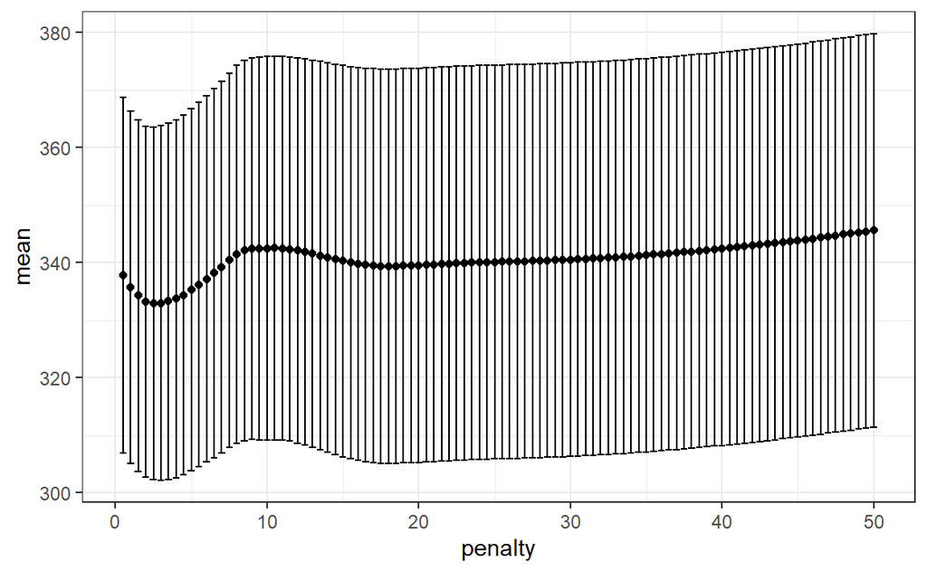

```r
p <- hitters_tune %>%
  collect_metrics() %>%
  filter(.metric == "rmse") %>%
  ggplot(aes(penalty, mean)) +
  geom_point() +
  geom_errorbar(aes(ymin = mean - std_err, ymax = mean + std_err))
p
```

```r
plotly::ggplotly(p)
```

[interactive chart not shown]

```r
show_best(hitters_tune, metric = "rmse", n = 10)
```

```
## # A tibble: 10 × 7
##    penalty .metric .estimator  mean     n std_err .config
##      <dbl> <chr>   <chr>      <dbl> <int>   <dbl> <chr>
##  1     2.5 rmse    standard    333.    10    30.6 Preprocessor1_Model005
##  2     3   rmse    standard    333.    10    30.8 Preprocessor1_Model006
##  3     2   rmse    standard    333.    10    30.4 Preprocessor1_Model004
##  4     3.5 rmse    standard    333.    10    31.0 Preprocessor1_Model007
##  5     4   rmse    standard    334.    10    31.1 Preprocessor1_Model008
##  6     1.5 rmse    standard    334.    10    30.5 Preprocessor1_Model003
##  7     4.5 rmse    standard    334.    10    31.3 Preprocessor1_Model009
##  8     5   rmse    standard    335.    10    31.4 Preprocessor1_Model010
##  9     1   rmse    standard    336.    10    30.6 Preprocessor1_Model002
## 10     5.5 rmse    standard    336.    10    31.6 Preprocessor1_Model011
```

```r
(M1 <- select_best(hitters_tune, metric = "rmse"))
```

```
## # A tibble: 1 × 2
##   penalty .config
##     <dbl> <chr>
## 1     2.5 Preprocessor1_Model005
```

```r
M2 <- select_by_one_std_err(hitters_tune, metric = "rmse", penalty)
select_by_pct_loss(hitters_tune, metric = "rmse", penalty, limit = 5)
```

```
## # A tibble: 1 × 2
##   penalty .config
##     <dbl> <chr>
## 1     0.5 Preprocessor1_Model001
```

## 6.5 Finalise the Model

```r
hitters_final_model <- hitters_wf %>% finalize_workflow(M1)
hitters_final_model
```

```
## ══ Workflow ════════════════════════════════════════════════════════════════════
## Preprocessor: Recipe
## Model: linear_reg()
##
## ── Preprocessor ────────────────────────────────────────────────────────────────
## 2 Recipe Steps
##
## • step_normalize()
## • step_dummy()
##
## ── Model ───────────────────────────────────────────────────────────────────────
## Linear Regression Model Specification (regression)
##
## Main Arguments:
##   penalty = 2.5
##   mixture = 1
##
## Computational engine: glmnet
```

## 6.6 Variable Importance

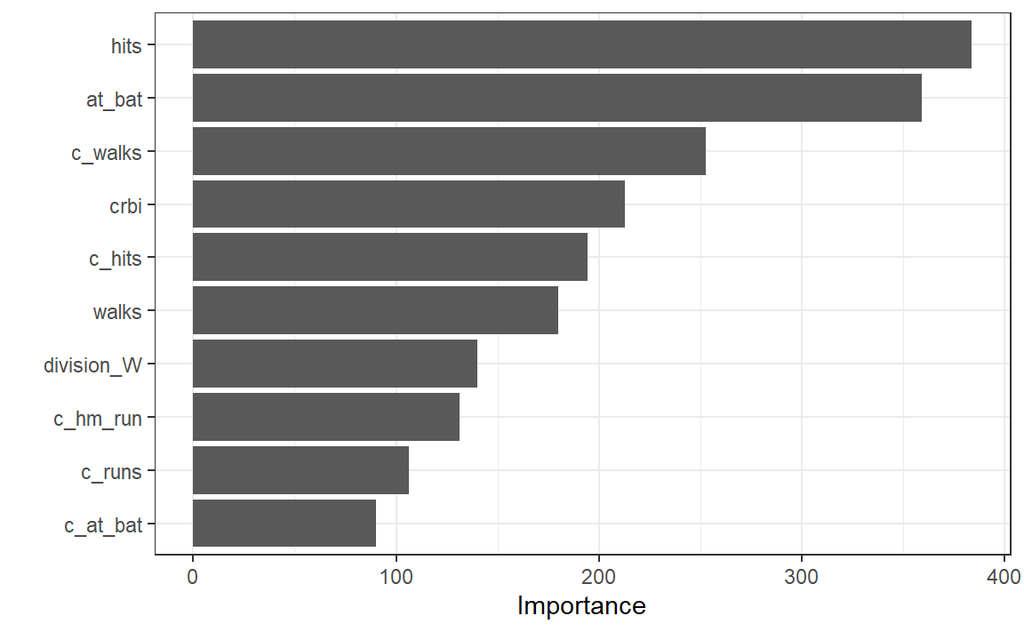

```r
hitters_final_model %>%
  fit(hitters_train) %>%
  extract_fit_parsnip() %>%
  vip()
```

## 6.7 Evaluate Model Performance Using Testing Data

```r
hitters_final_model %>% last_fit(hitters_split) %>% collect_metrics()
```

```
## # A tibble: 2 × 4
##   .metric .estimator .estimate .config
##   <chr>   <chr>          <dbl> <chr>
## 1 rmse    standard     341.    Preprocessor1_Model1
## 2 rsq     standard       0.431 Preprocessor1_Model1
```

```r
hitters_test %>%
  add_column(hitters_final_model %>%
               fit(data = hitters_train) %>%
               predict(new_data = hitters_test)) %>%
  rmse(salary, .pred)
```

```
## # A tibble: 1 × 3
##   .metric .estimator .estimate
##   <chr>   <chr>          <dbl>
## 1 rmse    standard        341.
```

# 7 DS_CS07_Decision_Trees_Titanic

## 7.1 Libs

```r
pacman::p_load(tidyverse, tidymodels, janitor, visNetwork)
```

## 7.2 Load data

```r
data("titanic_train", package = "titanic")
titanic <- as_tibble(titanic_train)
titanic
```

```
## # A tibble: 891 × 12
##    PassengerId Survived Pclass Name   Sex     Age SibSp Parch Ticket  Fare Cabin
##          <int>    <int>  <int> <chr>  <chr> <dbl> <int> <int> <chr>  <dbl> <chr>
##  1           1        0      3 Braun… male     22     1     0 A/5 2…  7.25 ""
##  2           2        1      1 Cumin… fema…    38     1     0 PC 17… 71.3  "C85"
##  3           3        1      3 Heikk… fema…    26     0     0 STON/…  7.92 ""
##  4           4        1      1 Futre… fema…    35     1     0 113803 53.1  "C12…
##  5           5        0      3 Allen… male     35     0     0 373450  8.05 ""
##  6           6        0      3 Moran… male     NA     0     0 330877  8.46 ""
##  7           7        0      1 McCar… male     54     0     0 17463  51.9  "E46"
##  8           8        0      3 Palss… male      2     3     1 349909 21.1  ""
##  9           9        1      3 Johns… fema…    27     0     2 347742 11.1  ""
## 10          10        1      2 Nasse… fema…    14     1     0 237736 30.1  ""
## # ℹ 881 more rows
## # ℹ 1 more variable: Embarked <chr>
```

## 7.3 Clean names

```r
titanic <- titanic %>% clean_names()
titanic
```

```
## # A tibble: 891 × 12
##    passenger_id survived pclass name       sex     age sib_sp parch ticket  fare
##           <int>    <int>  <int> <chr>      <chr> <dbl>  <int> <int> <chr>  <dbl>
##  1            1        0      3 Braund, M… male     22      1     0 A/5 2…  7.25
##  2            2        1      1 Cumings, … fema…    38      1     0 PC 17… 71.3
##  3            3        1      3 Heikkinen… fema…    26      0     0 STON/…  7.92
##  4            4        1      1 Futrelle,… fema…    35      1     0 113803 53.1
##  5            5        0      3 Allen, Mr… male     35      0     0 373450  8.05
##  6            6        0      3 Moran, Mr… male     NA      0     0 330877  8.46
##  7            7        0      1 McCarthy,… male     54      0     0 17463  51.9
##  8            8        0      3 Palsson, … male      2      3     1 349909 21.1
##  9            9        1      3 Johnson, … fema…    27      0     2 347742 11.1
## 10           10        1      2 Nasser, M… fema…    14      1     0 237736 30.1
## # ℹ 881 more rows
## # ℹ 2 more variables: cabin <chr>, embarked <chr>
```

## 7.4 Convert survived, pclass to factor

```r
titanic <- titanic %>%
  mutate_at(vars(survived, pclass, sex), factor)
titanic
```

```
## # A tibble: 891 × 12
##    passenger_id survived pclass name       sex     age sib_sp parch ticket  fare
##           <int> <fct>    <fct>  <chr>      <fct> <dbl>  <int> <int> <chr>  <dbl>
##  1            1 0        3      Braund, M… male     22      1     0 A/5 2…  7.25
##  2            2 1        1      Cumings, … fema…    38      1     0 PC 17… 71.3
##  3            3 1        3      Heikkinen… fema…    26      0     0 STON/…  7.92
##  4            4 1        1      Futrelle,… fema…    35      1     0 113803 53.1
##  5            5 0        3      Allen, Mr… male     35      0     0 373450  8.05
##  6            6 0        3      Moran, Mr… male     NA      0     0 330877  8.46
##  7            7 0        1      McCarthy,… male     54      0     0 17463  51.9
##  8            8 0        3      Palsson, … male      2      3     1 349909 21.1
##  9            9 1        3      Johnson, … fema…    27      0     2 347742 11.1
## 10           10 1        2      Nasser, M… fema…    14      1     0 237736 30.1
## # ℹ 881 more rows
## # ℹ 2 more variables: cabin <chr>, embarked <chr>
```

## 7.5 Select survived, pclass, age, sib_sp, parch

```r
titanic <- titanic %>% select(survived, pclass, sex, age, sib_sp, parch)
titanic
```

```
## # A tibble: 891 × 6
##    survived pclass sex      age sib_sp parch
##    <fct>    <fct>  <fct>  <dbl>  <int> <int>
##  1 0        3      male      22      1     0
##  2 1        1      female    38      1     0
##  3 1        3      female    26      0     0
##  4 1        1      female    35      1     0
##  5 0        3      male      35      0     0
##  6 0        3      male      NA      0     0
##  7 0        1      male      54      0     0
##  8 0        3      male       2      3     1
##  9 1        3      female    27      0     2
## 10 1        2      female    14      1     0
## # ℹ 881 more rows
```

## 7.6 Set recipe

```r
titanc_recipe <- recipe(survived ~ ., data = titanic)
```

## 7.7 Set model

```r
titanic_model <- decision_tree(mode = "classification") %>%
  set_engine("rpart")
```

## 7.8 Set workflow

```r
titanic_wf <- workflow() %>%
  add_recipe(titanc_recipe) %>%
  add_model(titanic_model)
```

## 7.9 Fit model

```r
titanic_fit <- titanic_wf %>% fit(titanic) %>% pull_workflow_fit()
titanic_fit
```

```
## parsnip model object
##
## n= 891
##
## node), split, n, loss, yval, (yprob)
##       * denotes terminal node
##
##  1) root 891 342 0 (0.61616162 0.38383838)
##    2) sex=male 577 109 0 (0.81109185 0.18890815)
##      4) age>=6.5 553  93 0 (0.83182640 0.16817360) *
##      5) age< 6.5 24   8 1 (0.33333333 0.66666667)
##       10) sib_sp>=2.5 9   1 0 (0.88888889 0.11111111) *
##       11) sib_sp< 2.5 15   0 1 (0.00000000 1.00000000) *
##    3) sex=female 314  81 1 (0.25796178 0.74203822)
##      6) pclass=3 144  72 0 (0.50000000 0.50000000)
##       12) sib_sp>=2.5 18   3 0 (0.83333333 0.16666667) *
##       13) sib_sp< 2.5 126  57 1 (0.45238095 0.54761905)
##         26) age>=38.5 12   1 0 (0.91666667 0.08333333) *
##         27) age< 38.5 114  46 1 (0.40350877 0.59649123) *
##      7) pclass=1,2 170   9 1 (0.05294118 0.94705882) *
```

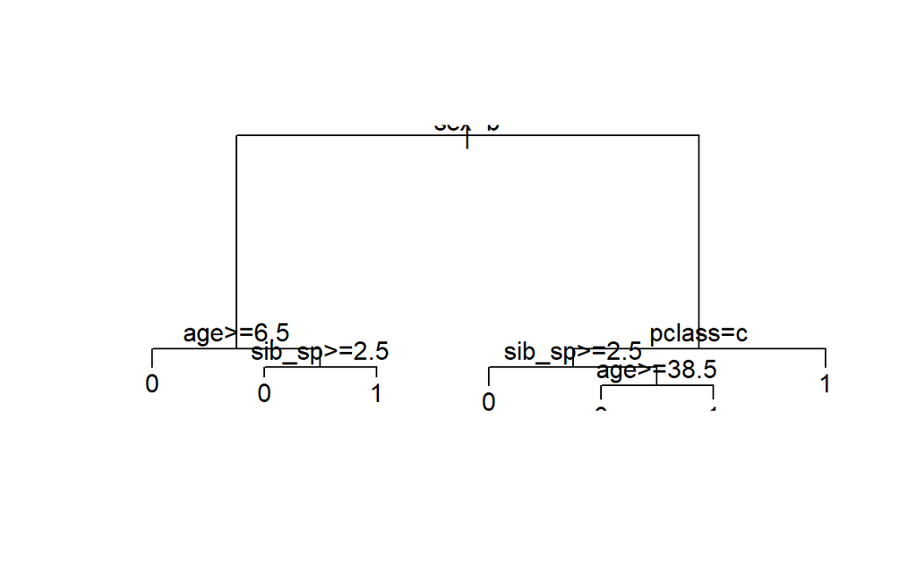

```r
plot(titanic_fit$fit)
text(titanic_fit$fit)
```

```r
visTree(titanic_fit$fit)
```

[interactive chart not shown]

## 7.10 Predict

```r
jono <- tibble(
  pclass = "3",
  sex = "male",
  age = 51,
  sib_sp = 1,
  parch = 0
)
predict(titanic_fit, new_data = jono)
```

```
## # A tibble: 1 × 1
##   .pred_class
##   <fct>
## 1 0
```

```r
predict(titanic_fit, new_data = jono, type = "prob")
```

```
## # A tibble: 1 × 2
##   .pred_0 .pred_1
##     <dbl>   <dbl>
## 1   0.832   0.168
```

# 8 DS_CS08_SVM_Board_Game

## 8.1 Load data

```r
tuesdata <- tidytuesdayR::tt_load("2019-03-12")
board <- tuesdata$board_games
write_rds(board, glue::glue("{wdpath}/data/board.rds"))
```

```r
board <- read_rds(glue::glue("{wdpath}/data/board.rds"))
```

## 8.2 Clean up

```r
board <-
  board %>%
  select(
    rating = average_rating,
    time = playing_time,
    year = year_published
  )
board
```

```
## # A tibble: 10,532 × 3
##    rating  time  year
##     <dbl> <dbl> <dbl>
##  1   7.67   240  1986
##  2   6.61    30  1981
##  3   7.44    60  1998
##  4   6.61    60  1992
##  5   7.36    90  1964
##  6   6.53   240  1989
##  7   6.51    20  1978
##  8   6.15   120  1993
##  9   6.52    90  1998
## 10   6.75    60  1998
## # ℹ 10,522 more rows
```

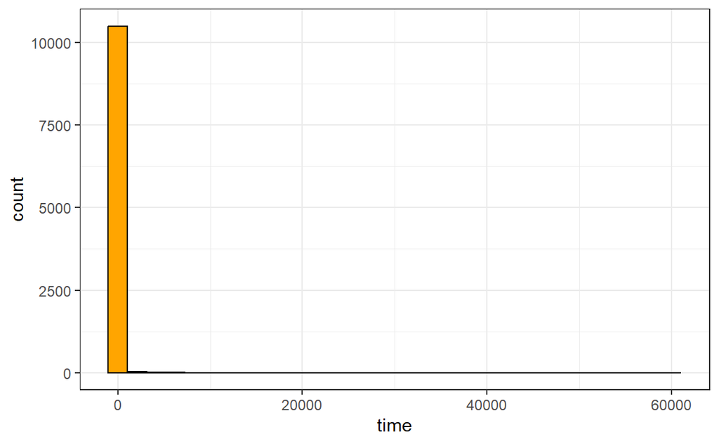

```r
board %>% ggplot(aes(time)) + geom_histogram(col = "black", fill = "orange")
```

```r
board <-
  board %>%
  filter(time > 0, time <= 360)
```

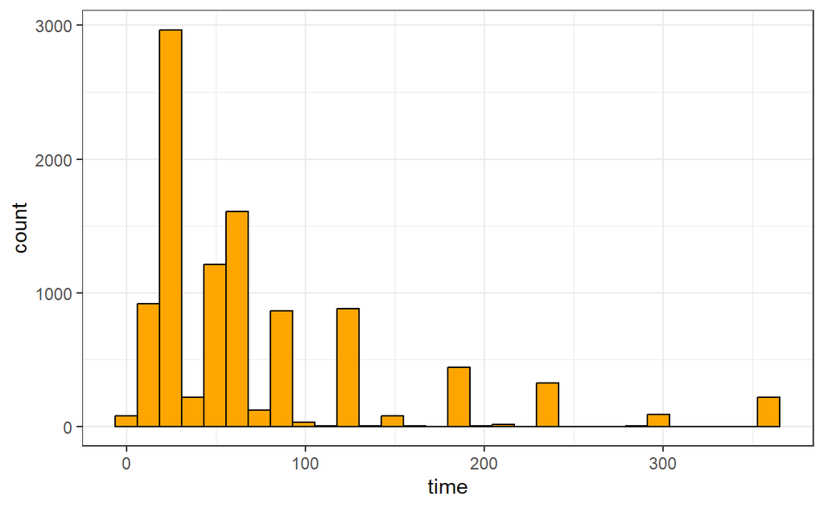

```r
board %>% ggplot(aes(time)) + geom_histogram(col = "black", fill = "orange")
```

Convert rating into three levels

```r
board <-
  board %>%
  mutate(
    rating = cut_number(
      rating, 3,
      labels = c("pants", "yeah", "wow")
    )
  )
```

## 8.3 EDA

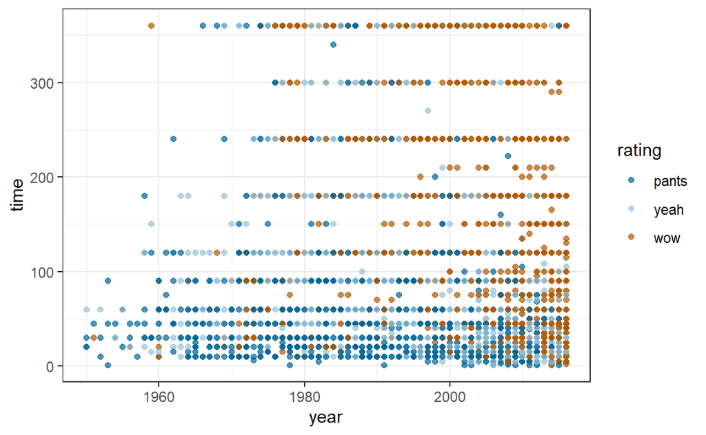

```r
board %>%
  ggplot(aes(year, time,
             col = rating)) +
  geom_point(alpha = 0.7) +
  scale_colour_hp(house = "ravenclaw", discrete = TRUE)
```

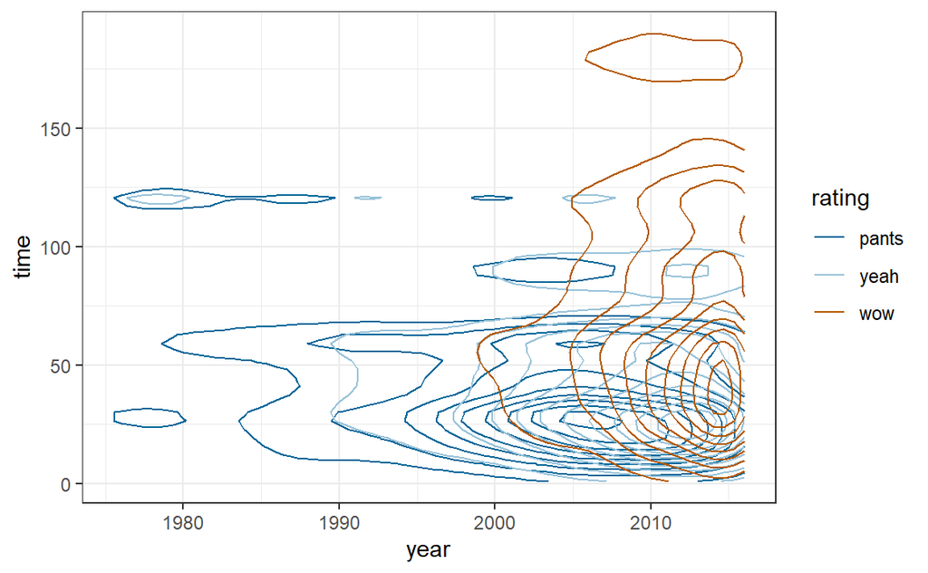

```r
board %>%
  ggplot(aes(year, time,
             col = rating)) +
  geom_density_2d() +
  scale_colour_hp(house = "ravenclaw", discrete = TRUE)
```

## 8.4 Model

```r
board_wf <-
  workflow() %>%
  add_recipe(
    recipe(rating ~ ., data = board) %>%
      step_log(time)
  ) %>%
  add_model(
    svm_poly(mode = "classification", degree = 2) %>%
      set_engine("kernlab")
  )
```

```r
board_M1 <- board_wf %>% fit(board)
board_M1
```

```
## ══ Workflow [trained] ══════════════════════════════════════════════════════════
## Preprocessor: Recipe
## Model: svm_poly()
##
## ── Preprocessor ────────────────────────────────────────────────────────────────
## 1 Recipe Step
##
## • step_log()
##
## ── Model ───────────────────────────────────────────────────────────────────────
## Support Vector Machine object of class "ksvm"
##
## SV type: C-svc  (classification)
##  parameter : cost C = 1
##
## Polynomial kernel function.
##  Hyperparameters : degree =  2  scale =  1  offset =  1
##
## Number of Support Vectors : 8611
##
## Objective Function Value : -5606.772 -3687.363 -4878.051
## Training error : 0.470489
## Probability model included.
```

```r
board_M2 <-
  board_wf %>%
  update_model(
    svm_rbf(mode = "classification") %>%
      set_engine("kernlab")
  ) %>%
  fit(board)
```

```r
board_M3 <-
  board_wf %>%
  update_model(
    rand_forest(mode = "classification") %>%
      set_engine("ranger")
  ) %>%
  fit(board)
```

## 8.5 Predict

```r
newdata <- crossing(
  year = seq(1980, 2016, length = 100),
  time = seq(1, 360, length = 100)
)
```

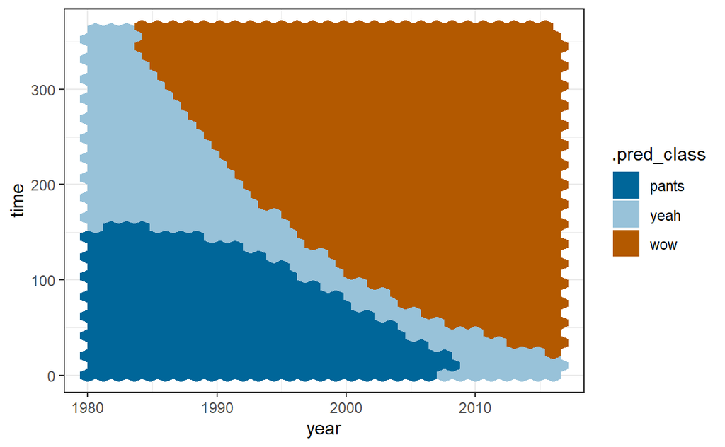

```r
newdata %>%
  add_column(
    predict(board_M1, new_data = newdata)
  ) %>%
  ggplot(aes(year, time, fill = .pred_class)) +
  geom_hex() +
  scale_fill_hp(house = "ravenclaw", discrete = TRUE)
```

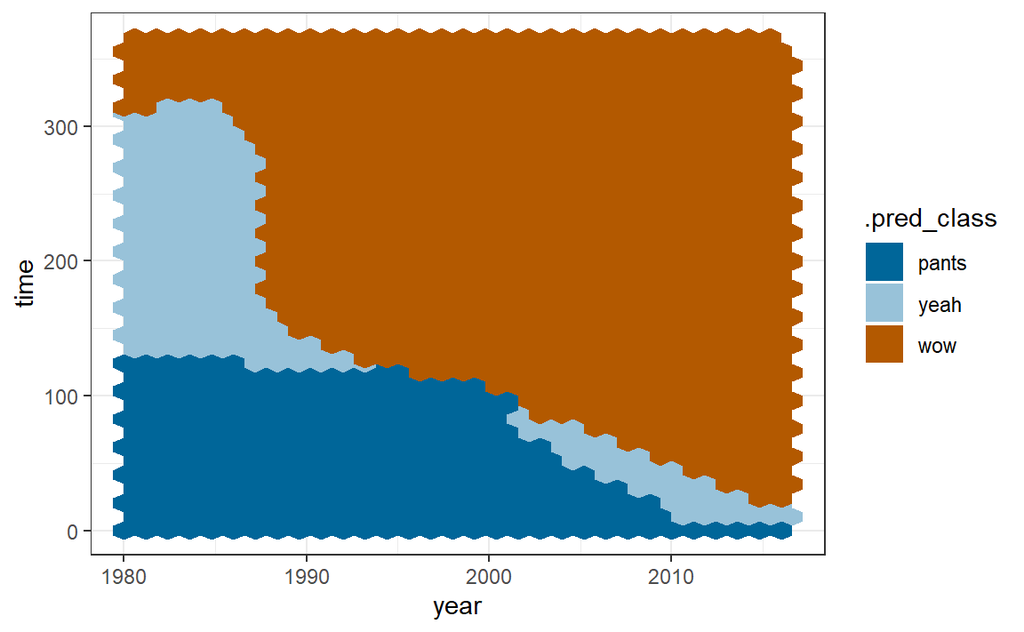

```r
newdata %>%
  add_column(
    predict(board_M2, new_data = newdata)
  ) %>%
  ggplot(aes(year, time, fill = .pred_class)) +
  geom_hex() +
  scale_fill_hp(house = "ravenclaw", discrete = TRUE)
```

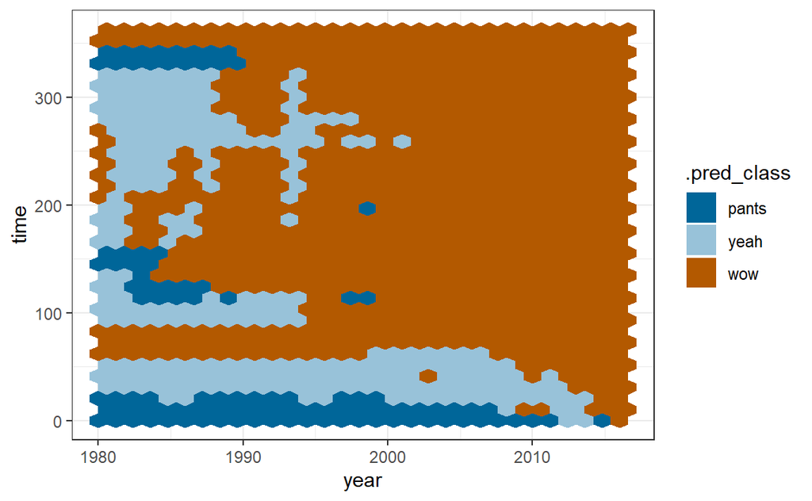

```r
newdata %>%
  add_column(
    predict(board_M3, new_data = newdata)
  ) %>%
  ggplot(aes(year, time, fill = .pred_class)) +
  geom_hex() +
  scale_fill_hp(house = "ravenclaw", discrete = TRUE)
```

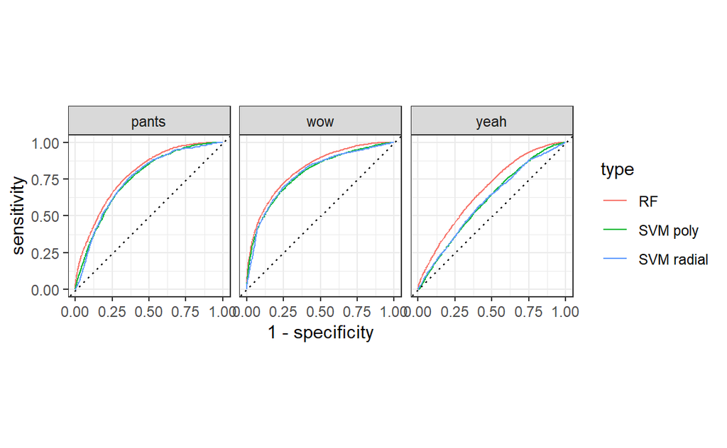

```r
board %>%
  add_column(
    predict(board_M1, new_data = board, type = "prob")
  ) %>%
  mutate(type = "SVM poly") %>%
  bind_rows(
    board %>%
      add_column(
        predict(board_M2, new_data = board, type = "prob")
      ) %>%
      mutate(type = "SVM radial")
  ) %>%
  bind_rows(
    board %>%
      add_column(
        predict(board_M3, new_data = board, type = "prob")
      ) %>%
      mutate(type = "RF")
  ) %>%
  group_by(type) %>%
  roc_curve(rating, starts_with(".pred")) %>%
  autoplot()
```

# 9 DS_CS09_PCA_Spotify

## 9.1 Read in data

```r
spotify <- read_rds(glue::glue("{wdpath}/data/spotify.rds"))
spotify
```

```
## # A tibble: 32,833 × 23
##    track_id              track_name track_artist track_popularity track_album_id
##    <chr>                 <chr>      <chr>                   <dbl> <chr>
##  1 6f807x0ima9a1j3VPbc7… I Don't C… Ed Sheeran                 66 2oCs0DGTsRO98…
##  2 0r7CVbZTWZgbTCYdfa2P… Memories … Maroon 5                   67 63rPSO264uRjW…
##  3 1z1Hg7Vb0AhHDiEmnDE7… All the T… Zara Larsson               70 1HoSmj2eLcsrR…
##  4 75FpbthrwQmzHlBJLuGd… Call You … The Chainsm…               60 1nqYsOef1yKKu…
##  5 1e8PAfcKUYoKkxPhrHqw… Someone Y… Lewis Capal…               69 7m7vv9wlQ4i0L…
##  6 7fvUMiyapMsRRxr07cU8… Beautiful… Ed Sheeran                 67 2yiy9cd2QktrN…
##  7 2OAylPUDDfwRGfe0lYql… Never Rea… Katy Perry                 62 7INHYSeusaFly…
##  8 6b1RNvAcJjQH73eZO4BL… Post Malo… Sam Feldt                  69 6703SRPsLkS4b…
##  9 7bF6tCO3gFb8INrEDcjN… Tough Lov… Avicii                     68 7CvAfGvq4RlIw…
## 10 1IXGILkPm0tOCNeq00kC… If I Can'… Shawn Mendes               67 4QxzbfSsVryEQ…
## # ℹ 32,823 more rows
## # ℹ 18 more variables: track_album_name <chr>, track_album_release_date <chr>,
## #   playlist_name <chr>, playlist_id <chr>, playlist_genre <chr>,
## #   playlist_subgenre <chr>, danceability <dbl>, energy <dbl>, key <dbl>,
## #   loudness <dbl>, mode <dbl>, speechiness <dbl>, acousticness <dbl>,
## #   instrumentalness <dbl>, liveness <dbl>, valence <dbl>, tempo <dbl>,
## #   duration_ms <dbl>
```

## 9.2 Clean up

```r
spotify <-
  spotify %>%
  select(danceability:duration_ms, genre = playlist_genre)
spotify
```

```
## # A tibble: 32,833 × 13
##    danceability energy   key loudness  mode speechiness acousticness
##           <dbl>  <dbl> <dbl>    <dbl> <dbl>       <dbl>        <dbl>
##  1        0.748  0.916     6    -2.63     1      0.0583       0.102
##  2        0.726  0.815    11    -4.97     1      0.0373       0.0724
##  3        0.675  0.931     1    -3.43     0      0.0742       0.0794
##  4        0.718  0.93      7    -3.78     1      0.102        0.0287
##  5        0.65   0.833     1    -4.67     1      0.0359       0.0803
##  6        0.675  0.919     8    -5.38     1      0.127        0.0799
##  7        0.449  0.856     5    -4.79     0      0.0623       0.187
##  8        0.542  0.903     4    -2.42     0      0.0434       0.0335
##  9        0.594  0.935     8    -3.56     1      0.0565       0.0249
## 10        0.642  0.818     2    -4.55     1      0.032        0.0567
## # ℹ 32,823 more rows
## # ℹ 6 more variables: instrumentalness <dbl>, liveness <dbl>, valence <dbl>,
## #   tempo <dbl>, duration_ms <dbl>, genre <chr>
```

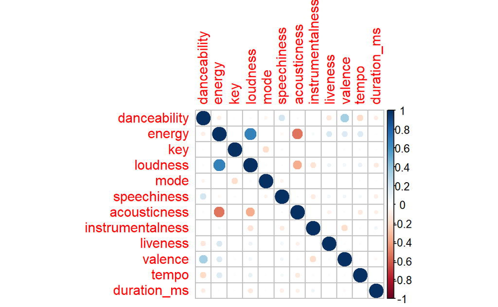

```r
pacman::p_load(corrplot)
spotify %>%
  select(danceability:duration_ms) %>%
  cor(use = "pairwise.complete.obs") %>%
  corrplot()
```

## 9.3 PCA

```r
spotify_prep <-
  spotify %>%
  recipe(genre ~ .) %>%
  step_normalize(all_predictors()) %>%
  step_pca(all_predictors(), num_comp = 4) %>%
  prep()
spotify_prep
```

```
## ── Recipe ──────────────────────────────────────────────────────────────────────
```

```
## ── Inputs
```

```
## Number of variables by role
```

```
## outcome:    1
## predictor: 12
```

```
## ── Training information
```

```
## Training data contained 32833 data points and no incomplete rows.
```

```
## ── Operations
```

```
## • Centering and scaling for: danceability, energy, key, ... | Trained
```

```
## • PCA extraction with: danceability, energy, key, loudness, ... | Trained
```

## 9.4 Loadings plot

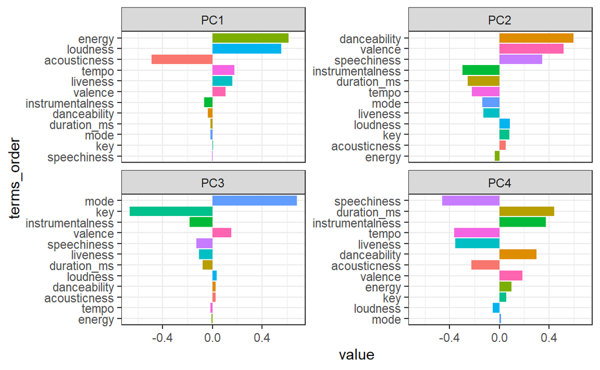

```r
pacman::p_load(tidytext)
spotify_prep %>%
  tidy(n = 2) %>%
  filter(component %in% c("PC1", "PC2", "PC3", "PC4")) %>%
  group_by(component) %>%
  top_n(5) %>%
  mutate(
    terms_order = reorder_within(terms, abs(value), component)
  ) %>%
  ggplot(
    aes(value, terms_order, fill = terms)
  ) +
  geom_col(show.legend = FALSE) +
  facet_wrap(~component, scales = "free_y") +
  scale_y_reordered()
```